# Final project

Digital Wings

# 1. Introduction

Social economic development significantly influences the quality of life of residents in a country or region. Therefore, it is important to understand different indicators of social economic development in a country to comprehensively evaluate the development levels across different regions and determine the crucial factors which contribute to their development disparities. The policy makers will be able to use these analyses as reference to formulate regional development plans and policies.

Peru is a developing country located in South America. Using the district level census data from Peru and multivariate analysis techniques, I aim at determining the major contributors of the differences in development levels.

# 2. Design, Primary Questions, and Planned analyses

- **Design**: In this study, I will use the key socioeconomic variables in a census conducted in Peru and conducted several multivariate analyses to understand the contribution of the variables to the socioeconomic disparity in different districts.
- **Question 1**: Can we translate multiple socioeconomic indicators into a few interpretable components?
  - Planned analysis: Principal component analysis (PCA)
- **Question 2**: How can we differentiate regions with varying levels of social development based on a set of socioeconomic indicators?
  - Planned analysis: Discriminant Analysis (DA)
- **Question 3**: Are the multivariate means different in different groups of districts?
  - Planned analysis: Multivariate analysis of variance (MANOVA)
- **Question 4**: Are there cluster of variables which move on similar directions?
  - Planned analysis: Cluster analysis for variables

# 3. Data source and description of variables

The database I use is a census data in Peru. The census data have a variety of demographical and social economic parameters (https://censos2017.inei.gob.pe/redatam/). I discussed with Dr. Reuning-Scherer and used the following variables in the final project:

`ubigeo` (character): District number (district ID)

`idh` (numeric): Human development index

`monetary_poverty` (numeric): Proportion of people meeting the criteria of poverty

`life_expectancy` (numeric): Life expectancy

`complete_secondary_edu` (numeric): Proportion of people complete secondary education 70%-90%

`years_edu` (numeric): Average years of education

`family_income` (numeric): Average family income

`number_hh` (numeric): Number of households participating in the census

`hh_1_nbi_or_more` (numeric): Number of households with one or more unmet need (Before data wrangling)/ Proportion of family with 1 or more unmet need (After data wrangling)

`hh_wo_sanitation` (numeric): Number of households without sanitation (Before data wrangling)/ Proportion of households without sanitation (After data wrangling)

**Note**: The categorical variables required for discriminant analysis and MANOVA will be created in the corresponding parts (7.1 and 8.1).

# 4. Data wrangling

During the discussion of the dataset with Dr. Reuning-Scherer, he suggested me to convert the variables related to number of household into proportion. The number of household participating in the census is used as denominators and is removed after the proportions are calculated. Also, he suggested it was better not to include many codes in the report. So the codes were not shown in most parts of the report for the purpose of conciseness. There is a html version with all the codes in [my github page](https://github.com/dwingspixel563/Final-project-S-DS-563) https://github.com/dwingspixel563/Final-project-S-DS-563 for your reference.

```r
data1 <- read.csv('data/data_census.csv')
data1 <- data1 %>% mutate(hh_1_nbi_or_more = hh_1_nbi_or_more/number_hh,
                          hh_wo_sanitation = hh_wo_sanitation/number_hh) %>% dplyr::select(-number_hh)
```

There might also be specific data wrangling for different analyses in the analyses parts if needed. For example, in the discriminant analysis part, I will create a categorical data hdi_cat based on idh (human development index) variable.

# 5. Descriptive analyses, plots and summary statistics

## 5.1 Distribution of the variables

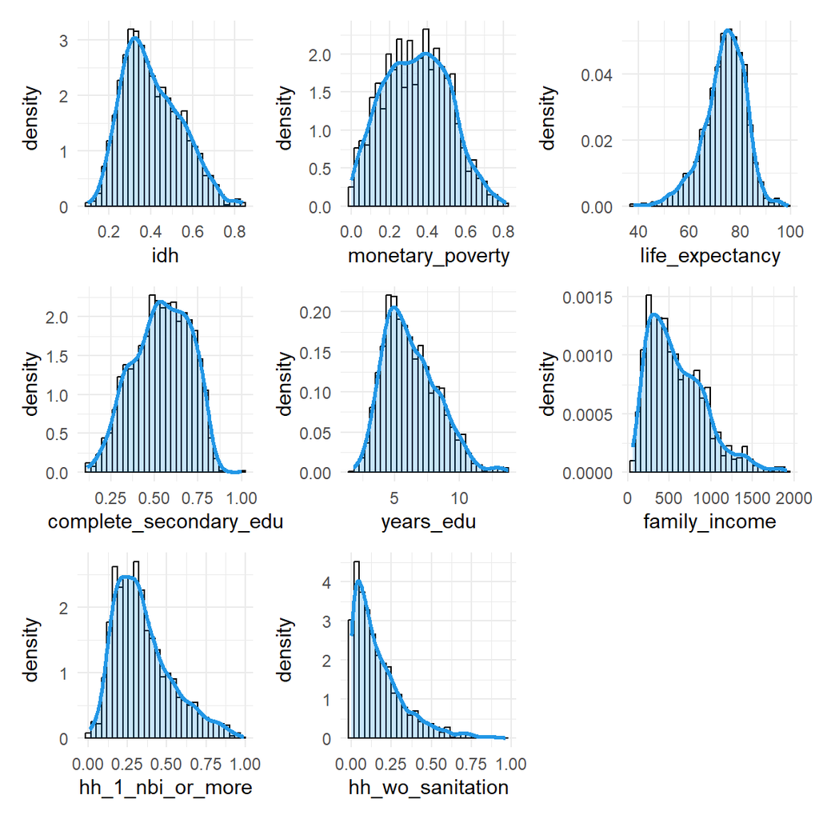

```r
plot_list <- list()
for (i in 2:9) {
  plot_list[[i-1]] <- data1 %>% ggplot(aes(x = .data[[names(data1)[i]]]))+
    geom_histogram(aes(y = ..density..),
                 colour = 1, fill = "white") +
  geom_density(lwd = 1, colour = 4,
               fill = 4, alpha = 0.25) +
  theme_minimal()
}

plot_layout <- wrap_plots(plot_list, ncol = 3, nrow = 3)
plot_layout
```

It seems that hh_1_nbi_or_more, hh_wo_santiation and family_income are severely skewed.

## 5.2 Boxplots of the variables

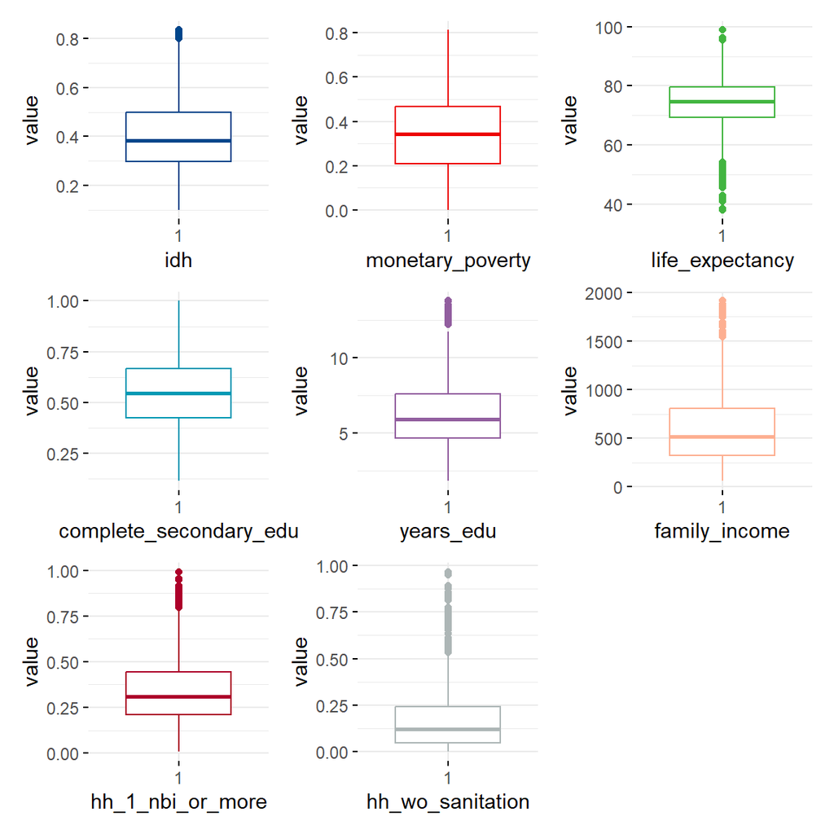

```r
boxplot_list <- list()
names_var <- names(data1)[-1]
colors <- pal_lancet()(8)
for (number in 1:8) {
boxplot_list[[number]] <- ggboxplot(data1, y = names_var[number],
                            xlab =  names_var[number], ylab = 'value',
                            color = colors[number],
                            ggtheme = theme_minimal())

}
boxplot_layout <- wrap_plots(boxplot_list, ncol = 3, nrow = 3)
boxplot_layout
```

## 5.3 Table for summary statistics

```r
data1 %>%
  tbl_summary(include = names(data1)[-1]) %>%
  modify_header(label = "**Variable**")
```

| **Variable** | **N = 1,874**<sup>1</sup> |
| --- | --- |
| idh | 0.38 (0.30, 0.50) |
| monetary_poverty | 0.34 (0.21, 0.47) |
| life_expectancy | 75 (69, 80) |
| complete_secondary_edu | 0.55 (0.43, 0.67) |
| years_edu | 5.89 (4.65, 7.57) |
| family_income | 519 (325, 808) |
| hh_1_nbi_or_more | 0.31 (0.21, 0.44) |
| hh_wo_sanitation | 0.12 (0.05, 0.24) |

<sup>1</sup> Median (IQR)

## 5.4 Correlation of the variables

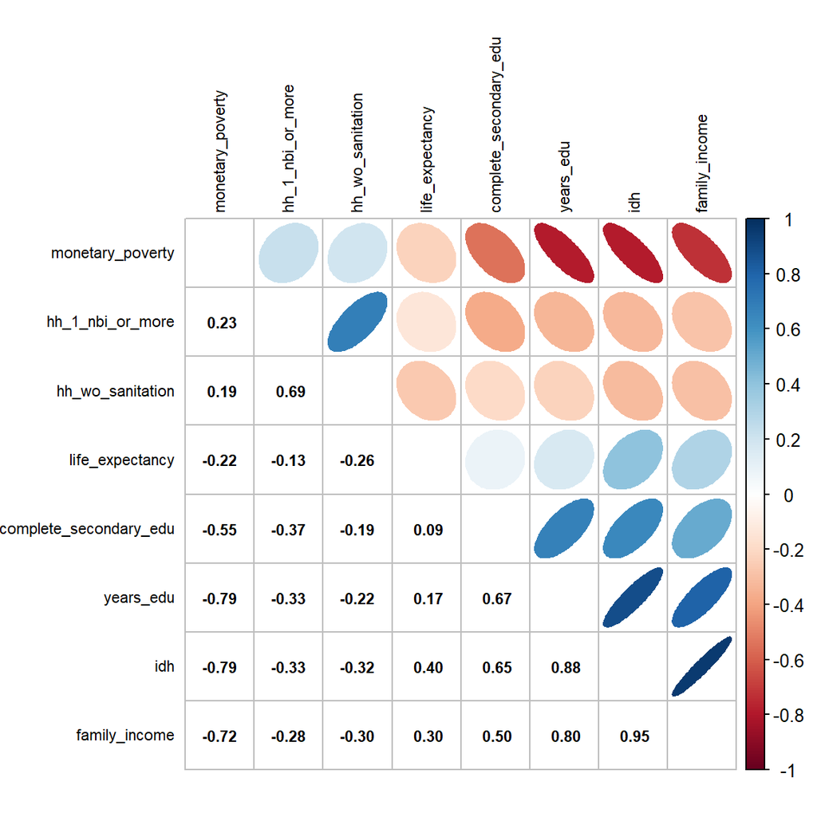

```r
corrplot.mixed(cor(data1[,-1]), lower.col = "black", upper = "ellipse", tl.col = "black",
               number.cex=.7, order = "hclust", tl.pos = "lt", tl.cex=.7)
```

# 6. Multivariate analysis 1: Principal Component Analysis

## 6.1 Preparation for PCA

### 6.1.1 Multivariate normal distribution check

Though PCA does not require multivariate normal distribution, parallel analysis requires the multivariate normal distribution. Therefore, I have a look at the multivariate chi-square quantile plot of my data.

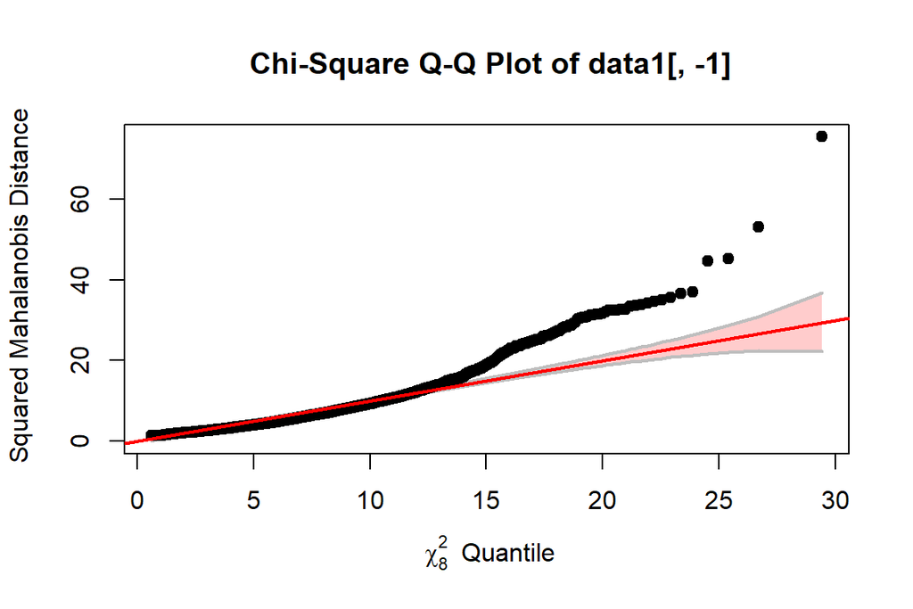

```r
cqplot(data1[,-1])
```

After discussion with Dr. Reuning-Scherer, I tried logit transformation of the proportions and idh (which are between 0-1), and do log transformation to other variables, to see whether it will improve the multivariate normal distribution of my data

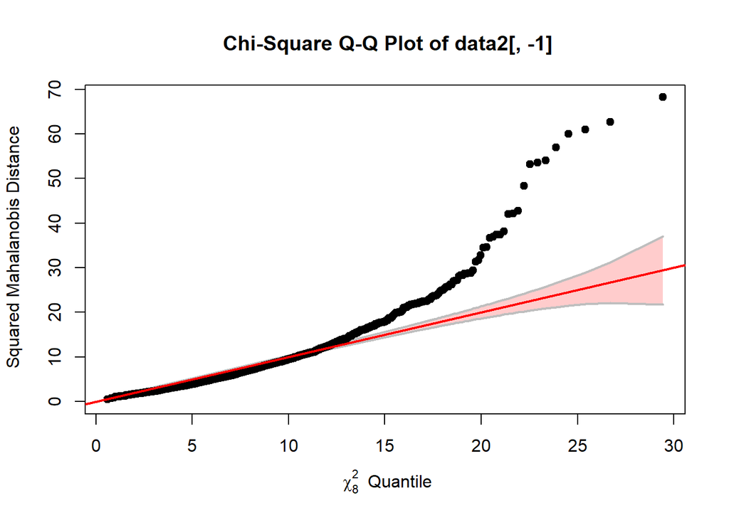

```r
data2 <- data1 %>%
  mutate_at(vars(c("idh","monetary_poverty", "complete_secondary_edu",
"hh_1_nbi_or_more", "hh_wo_sanitation")),
function(x) car::logit(x,adjust = 0.025)) %>%
mutate_at(vars(c( "life_expectancy", "years_edu", "family_income")), function(x) log(x))

cqplot(data2[,-1])
```

It seems that the multivariate chi-square quantile plots are similar before and after transformation. If the data follow the multivariate normal distribution, the chi-square quantile plots will fit a line. But my data seem not fit a line very well. Therefore, my data do not seem to follow multivariate normal distribution very well. Dr. Reuning-Scherer suggested it would still be useful to have a look at the parallel analysis result, so I would give it a try in the later part. As the data transformation does not help to improve the multivariate normality, I will use the original data.

### 6.1.2 Correlation of the variables

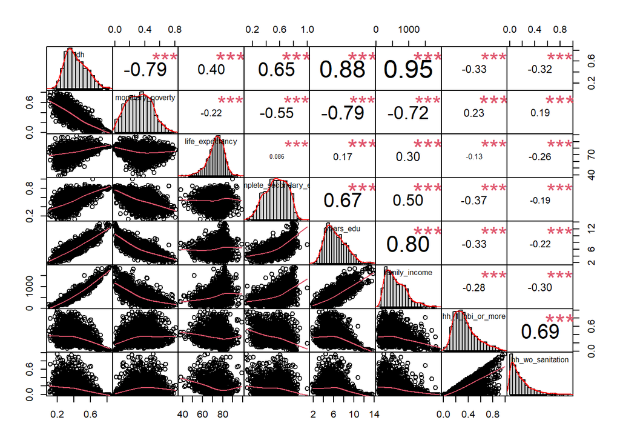

```r
chart.Correlation(data1[, -1])
```

I feel that PCA will work well on my data. PCA requires linear correlation between variables and will work better when variables are correlated. Most of my data are correlated and most of the correlations are linear.

## 6.2 PCA

In this step I did PCA first, and then tried different techniques to decide how many principal components to retain.

The results of the PCA are shown below:

```r
pc1 <- princomp(data1[,-1], cor = TRUE)
summary(pc1)
```

```
## Importance of components:
##                           Comp.1    Comp.2    Comp.3     Comp.4     Comp.5
## Standard deviation     2.0881222 1.1912480 0.9942346 0.71947510 0.54419060
## Proportion of Variance 0.5450318 0.1773840 0.1235628 0.06470555 0.03701793
## Cumulative Proportion  0.5450318 0.7224157 0.8459786 0.91068411 0.94770203
##                            Comp.6    Comp.7     Comp.8
## Standard deviation     0.51421344 0.3788920 0.10202510
## Proportion of Variance 0.03305193 0.0179449 0.00130114
## Cumulative Proportion  0.98075396 0.9986989 1.00000000
```

```r
#Get loadings
print(pc1$loadings, cutoff = 0, digits = 2)
```

```
##
## Loadings:
##                        Comp.1 Comp.2 Comp.3 Comp.4 Comp.5 Comp.6 Comp.7 Comp.8
## idh                     0.46   0.13   0.12   0.09   0.26   0.03   0.08   0.82
## monetary_poverty       -0.40  -0.23   0.01  -0.19   0.82   0.11  -0.24   0.03
## life_expectancy         0.18  -0.17   0.86  -0.40  -0.10   0.09  -0.08  -0.13
## complete_secondary_edu  0.35   0.09  -0.36  -0.76   0.12  -0.33   0.18  -0.12
## years_edu               0.43   0.19  -0.14   0.06   0.02   0.16  -0.83  -0.20
## family_income           0.43   0.14   0.12   0.37   0.46   0.09   0.41  -0.51
## hh_1_nbi_or_more       -0.24   0.62   0.29   0.10   0.12  -0.66  -0.14  -0.02
## hh_wo_sanitation       -0.22   0.68   0.00  -0.28  -0.03   0.63   0.14   0.01
##
##                Comp.1 Comp.2 Comp.3 Comp.4 Comp.5 Comp.6 Comp.7 Comp.8
## SS loadings      1.00   1.00   1.00   1.00   1.00   1.00   1.00   1.00
## Proportion Var   0.13   0.12   0.12   0.12   0.12   0.12   0.13   0.13
## Cumulative Var   0.13   0.25   0.37   0.50   0.62   0.75   0.88   1.00
```

### 6.2.1 Total variance explained by a given number of principal components

The Comp.1 explains ~55% variance, adding Comp.2 explains a cumulative ~ 72% variance, and adding Comp.3 explains ~85% variance. If I set 70% threshold, Comp.1 and Comp.2 will be retained. If I set 80% threshold, Comp.1, Comp.2, and Comp.3 will be retained.

### 6.2.2 The ‘eigenvalue > 1’ criteria

The eigenvalues are shown below:

```r
round(pc1$sdev^2,2)
```

```
## Comp.1 Comp.2 Comp.3 Comp.4 Comp.5 Comp.6 Comp.7 Comp.8
##   4.36   1.42   0.99   0.52   0.30   0.26   0.14   0.01
```

Using the ‘eigenvalue > 1’ criteria, Comp.1 and Comp.2 will be retained.

### 6.2.3 Scree plot elbow

The following plot contains information from both Scree plot (red line) and parallel analysis (blue and green lines).

```
##   pcompnum   longman     allen
## 1        1 1.0844335 0.9623039
## 2        2 1.0555372 0.9153875
## 3        3 1.0362903 0.8758775
## 4        4 1.0011837 0.8430059
## 5        5 0.9888085 0.8118847
## 6        6 0.9809496 0.7851424
## 7        7 0.9751637        NA
## 8        8 0.9737481        NA
```

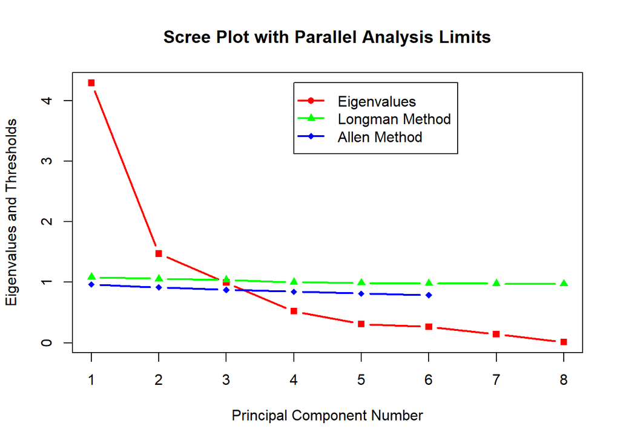

```r
source("http://www.reuningscherer.net/multivariate/R/parallel.r.txt")
data1x <- data1 %>% sample_n(999)
pc2 <- princomp(data1x[,-1], cor = TRUE)
#make the parallel analysis plot using the parallelplot function
parallelplot(pc2)
```

It seems that the elbow is at Comp.2, so Comp.1 and Comp.2 will be retained in screeplot method.

### 6.2.4 Parallel analysis

From the parallel analysis plot above, it is certain the Comp.1 and Comp.2 will be retained, while Comp.3 is a little bit ambiguous.

### 6.2.5 Summary of component choice

I will retain Comp.1 and Comp.2, as they have already explained most of the variance, and most methods support retaining the 2 components.

## 6.3 Interpretation of the principal components

The loadings of the principal components are as follows:

```r
## print the loadings
print(pc1$loadings, cutoff = 0, digits = 2)
```

```
##
## Loadings:
##                        Comp.1 Comp.2 Comp.3 Comp.4 Comp.5 Comp.6 Comp.7 Comp.8
## idh                     0.46   0.13   0.12   0.09   0.26   0.03   0.08   0.82
## monetary_poverty       -0.40  -0.23   0.01  -0.19   0.82   0.11  -0.24   0.03
## life_expectancy         0.18  -0.17   0.86  -0.40  -0.10   0.09  -0.08  -0.13
## complete_secondary_edu  0.35   0.09  -0.36  -0.76   0.12  -0.33   0.18  -0.12
## years_edu               0.43   0.19  -0.14   0.06   0.02   0.16  -0.83  -0.20
## family_income           0.43   0.14   0.12   0.37   0.46   0.09   0.41  -0.51
## hh_1_nbi_or_more       -0.24   0.62   0.29   0.10   0.12  -0.66  -0.14  -0.02
## hh_wo_sanitation       -0.22   0.68   0.00  -0.28  -0.03   0.63   0.14   0.01
##
##                Comp.1 Comp.2 Comp.3 Comp.4 Comp.5 Comp.6 Comp.7 Comp.8
## SS loadings      1.00   1.00   1.00   1.00   1.00   1.00   1.00   1.00
## Proportion Var   0.13   0.12   0.12   0.12   0.12   0.12   0.13   0.13
## Cumulative Var   0.13   0.25   0.37   0.50   0.62   0.75   0.88   1.00
```

Comp.1 seems to be driven by human development index(idh, 0.46), poverty proportion (monetary_poverty, -0.40), proportion of completing secondary education (complete_secondary_edu, 0.35), years of education (years_edu, 0.43) and family income (family_income, 0.43). The Comp.1 seems to represent the wealthy level of the district. While family income is the direct measure of wealth, human development index, education year and complete_secondary_edu are indirect measures of wealth. The direction of Comp.1 is pointing towards higher wealth, as idh, years_edu, family_income has positive value, while monetary_poverty has negative value.

Comp.2 seems to be driven by hh_1_nbi_or_more (proportion of family with 1 or more unmet need, 0.62) and hh_wo_sanitation (proportion of family without sanitation, 0.68). Comp.2 seems to represent living conditions, as these two measures are the living conditions of the households. The direction of comp.2 points towards lower living condition, as both hh_1_nbi_or_more and hh_wo_sanitation have positive value.

## 6.4 Score plot and 95% Confidence Ellipse of the principal components

I made score plots with confidence ellipse as well as a biplot.

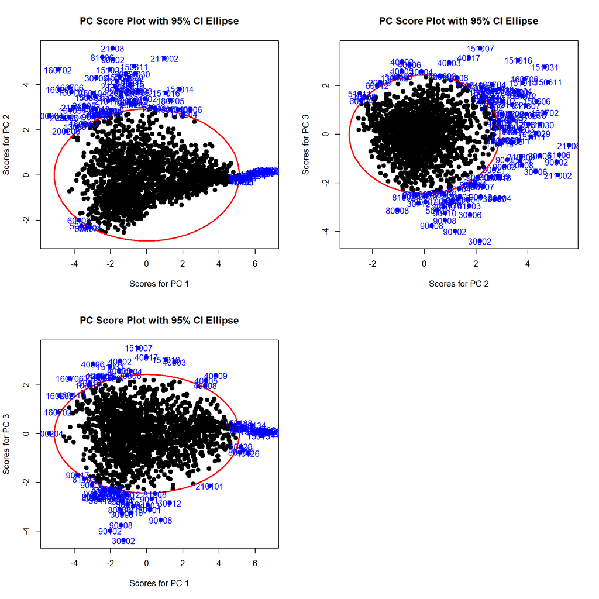

```r
source("http://reuningscherer.net/multivariate/r/ciscoreplot.R.txt")
par(mfcol = c(2, 2))
ciscoreplot(pc1, c(1, 2), data1[, 1])
ciscoreplot(pc1, c(1, 3), data1[, 1])
ciscoreplot(pc1, c(2, 3), data1[, 1])
```

From the score plots, it seems that there are some outliers. For example, in Comp.1 vs Comp.2 scoreplot, there are some districts which have negative PC1 (low wealth) but also have negative PC2 (good living condition). However, as the ellipse method assumes multivariate normal distribution and my data do not have a good fit to multivariate normal distribution, the “outliers” may actually be due to the skewed distribution but not real outliers. I discussed with Dr. Reuning-Scherer and think that the outliers in Comp.1 vs Comp.2 plot is more likely due to skewed distribution.

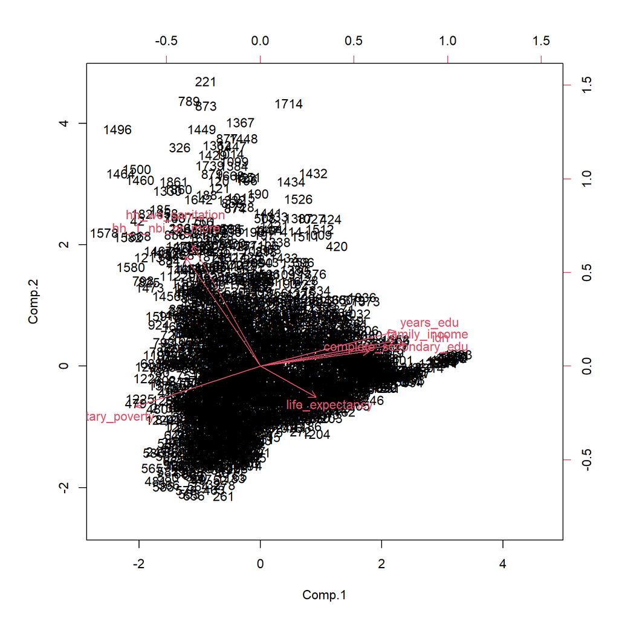

```r
par(mfcol = c(1, 1))
#make a biplot for first two components
biplot(pc1, choices = c(1, 2), pc.biplot = T)
```

## 6.5 Summary of PCA

In summary, the PCA reduces the dimensions of my data from 8 to 2. The two principal components are: 1. Wealth of the district: driven by human development index, proportion of completing secondary education, years of education and family income, and also a variable on the other direction (poverty proportion); 2. Living conditions of the district: driven by hh_1_nbi_or_more (proportion of family with 1 or more unmet need) and hh_wo_sanitation (proportion of family without sanitation). Most of the variability of the data (>70%) can be explained by the wealth and living condition of the district.

Also, according to the biplot above, the two principal components well represent the directions of the variables. We can easily identify two groups of variables. There are some outliers in higher dimensional spaces according to the scoreplot, but I feel they are mainly due to the distribution of the data are not multivariate normal. We have 1874 observations for 8 variables. The sample size is big enough for PCA.

# 7. Multivariate analysis 2: Discriminant Analysis

## 7.1 Data wrangling

For the purpose of discriminant analysis, I create a new categorical variable based on Human development index (HDI): HDI of less than 0.400 for low human development, 0.400–0.599 for medium human development, 0.600 or greater for high human development. The new variable is hdi_cat. The purpose of this category is to measure the relative development level within the country, so the category is based on the distribution of HDI within Peru and it is different from the HDI category criteria by UNDP. For the purpose of this analysis, as complete_secondary_edu is very relevant to years_edu and may compete in the DA model, I choose years_edu and remove complete_secondary_edu.

The number of district in each category in the hdi_cat variable is as follows:

```r
data_da <- data1 %>% mutate(hdi_cat = case_when(idh <0.400 ~ "low",
                                              idh >=0.400 & idh <0.600 ~ 'medium',
                                              idh >=0.600 ~ 'high'),
                          hdi_cat = fct_relevel(hdi_cat, "low", "medium", "high")) %>%
dplyr::select(-complete_secondary_edu)

table(data_da$hdi_cat, useNA = 'always')
```

```
##
##    low medium   high   <NA>
##   1018    670    186      0
```

## 7.2 Evaluate the assumptions implicit to Discriminant Analysis

### 7.2.1 Checking multivariate normality WITHIN each group

I first examined multivariate normality within each group

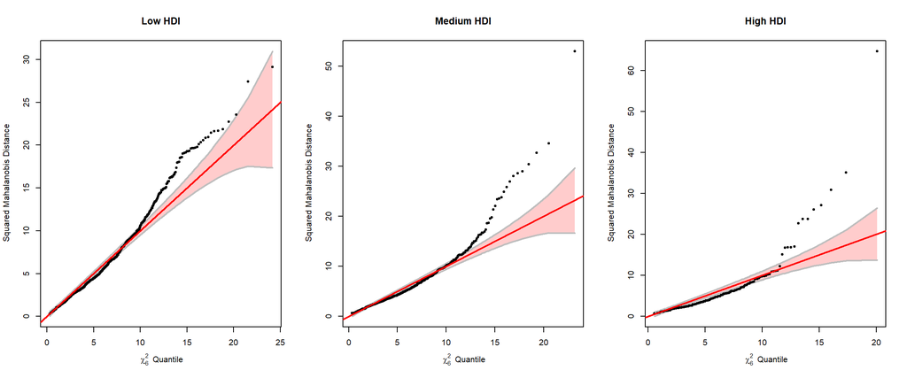

```r
par(mfcol = c(1, 3))
#examine multivariate normality within each group
cqplot(data_da[data_da$hdi_cat == 'low', c(3:8)],
       main = "Low HDI")
cqplot(data_da[data_da$hdi_cat == 'medium', c(3:8)],
       main = "Medium HDI")
cqplot(data_da[data_da$hdi_cat == 'high',c(3:8)],
       main = "High HDI")
```

Then, I also tried to exclude the proportion variables and see the plots

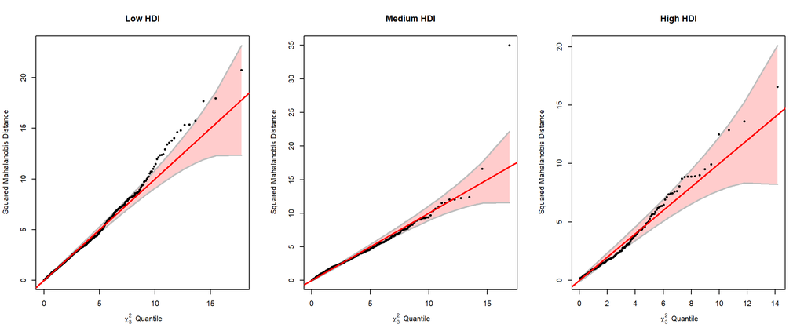

```r
par(mfcol = c(1, 3))
# Also I try to exclude the proportion variables and see the plots
cqplot(data_da[data_da$hdi_cat == 'low', c(4:6)], main = "Low HDI")
cqplot(data_da[data_da$hdi_cat == 'medium', c(4:6)], main = "Medium HDI")
cqplot(data_da[data_da$hdi_cat == 'high',c(4:6)], main = "High HDI")
```

```r
par(mfcol = c(1, 1))
```

The raw data seems to have multivariate normal distribution in low hdi group, but the data are not so close to multivariate normal in middle and high hdi group. Also, if I do not include the proportion variables, the multivariate normality is very well in all the three groups

### 7.2.2 Similarity of covariances matrices

I tried different combinations of important variables

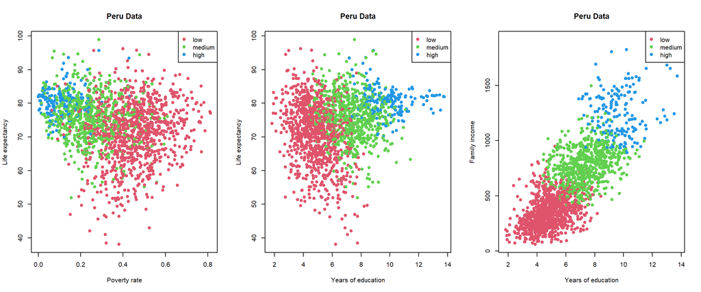

```r
par(mfcol = c(1, 3))
# I tried different combinations of important variables
plot(data_da$monetary_poverty, data_da$life_expectancy, col = as.numeric(data_da$hdi_cat)+1,
     pch = 19,
     main = "Peru Data", ylab = "Life expectancy",
     xlab = "Poverty rate")
legend("topright", col = c(2:4),
       legend = levels(data_da$hdi_cat), pch = 19)

plot(data_da$years_edu, data_da$life_expectancy, col = as.numeric(data_da$hdi_cat)+1, pch = 19, main = "Peru Data", ylab = "Life expectancy", xlab = "Years of education")
legend("topright", col = c(2:4), legend = levels(data_da$hdi_cat), pch = 19)
plot(data_da$years_edu, data_da$family_income, col = as.numeric(data_da$hdi_cat)+1, pch = 19, main = "Peru Data", ylab = "Family income", xlab = "Years of education")
legend("topright", col = c(2:4), legend = levels(data_da$hdi_cat), pch = 19)
```

```r
par(mfcol = c(1, 1))
```

Then I calculated Box’s M statistic

```r
#calculate Box's M statistic
boxM(data_da[,c("monetary_poverty","life_expectancy")], data_da$hdi_cat)
```

```
##
##  Box's M-test for Homogeneity of Covariance Matrices
##
## data:  data_da[, c("monetary_poverty", "life_expectancy")]
## Chi-Sq (approx.) = 279.26, df = 6, p-value < 2.2e-16
```

```r
boxM(data_da[,c("years_edu","life_expectancy")], data_da$hdi_cat)
```

```
##
##  Box's M-test for Homogeneity of Covariance Matrices
##
## data:  data_da[, c("years_edu", "life_expectancy")]
## Chi-Sq (approx.) = 215.87, df = 6, p-value < 2.2e-16
```

```r
boxM(data_da[,c("family_income","life_expectancy")], data_da$hdi_cat)
```

```
##
##  Box's M-test for Homogeneity of Covariance Matrices
##
## data:  data_da[, c("family_income", "life_expectancy")]
## Chi-Sq (approx.) = 284.68, df = 6, p-value < 2.2e-16
```

After trying the combinations of several different variables, it seems that the different groups do have similar foot prints in the plots. As I have a large database (n > 1000), Box’s M test is too sensitive and always result in significant P value and reject the null hypothesis. Therefore, for my data, Box’s M test may not be reliable. **Considering the similarity in foot prints in the plots and the large sample size, Dr. Reuning-Scherer suggested me to use linear DA, so I use linear DA in the later analyses.**

### 7.2.3 matrix plot

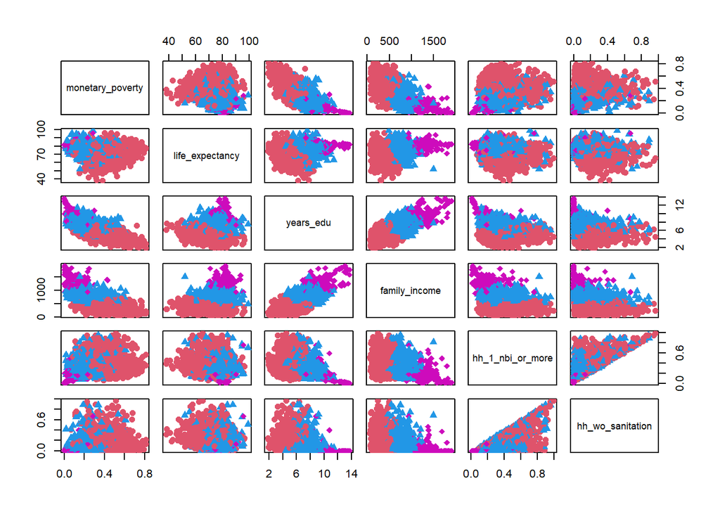

```r
plot(data_da[, c(3:8)], col = 2*(as.numeric(data_da$hdi_cat)), pch = as.numeric(data_da$hdi_cat)+15, cex = 1.2)
```

From the matrix plot we can see that years_edu, life_expectancy and family_income already do well in separating the groups. Also the household proportions are very skewed due to their connections. Considering the matrix plots and the proportion variables will have huge impact on the multivariate normality, **after discussing with Dr. Reuning-Scherer, I decided to only include non-proportion variables (years_edu, life_expectancy and family_income) in the DA.**

## 7.3 Discriminant analysis

### 7.3.1 Run DA in all the 3 variable

I first run DA in all the 3 variables mentioned before

```r
(data_da.disc.lda <- lda(data_da[, c(4,5,6)], grouping = data_da$hdi_cat))
```

```
## Call:
## lda(data_da[, c(4, 5, 6)], grouping = data_da$hdi_cat)
##
## Prior probabilities of groups:
##        low     medium       high
## 0.54322305 0.35752401 0.09925293
##
## Group means:
##        life_expectancy years_edu family_income
## low           71.31738  4.856627      349.9861
## medium        75.75592  7.317821      768.9363
## high          80.68205  9.822180     1278.3707
##
## Coefficients of linear discriminants:
##                         LD1          LD2
## life_expectancy 0.043195410 -0.032477476
## years_edu       0.368533983 -0.794668637
## family_income   0.004648207  0.004711078
##
## Proportion of trace:
##    LD1    LD2
## 0.9987 0.0013
```

Then I got the various kinds of coefficients.

```r
print("Raw (Unstandardized) Coefficients")
```

```
## [1] "Raw (Unstandardized) Coefficients"
```

```r
round(data_da.disc.lda$scaling,2)
```

```
##                  LD1   LD2
## life_expectancy 0.04 -0.03
## years_edu       0.37 -0.79
## family_income   0.00  0.00
```

```r
print("Normalized Coefficients")
```

```
## [1] "Normalized Coefficients"
```

```r
round(data_da.disc.lda$scaling/sqrt(sum(data_da.disc.lda$scaling^2)),2)
```

```
##                  LD1   LD2
## life_expectancy 0.05 -0.04
## years_edu       0.42 -0.91
## family_income   0.01  0.01
```

```r
print("Standardized Coefficients")
```

```
## [1] "Standardized Coefficients"
```

```r
round(lda(scale(data_da[, c(4,5,6)]), grouping = data_da$hdi_cat)$scaling, 2)
```

```
##                  LD1   LD2
## life_expectancy 0.36 -0.27
## years_edu       0.76 -1.64
## family_income   1.58  1.60
```

### 7.3.2 Stepwise DA in all the 3 variable

Then I used step DA method to see which variable(s) should be retained

```r
(step3 <- stepclass(hdi_cat ~ life_expectancy  + years_edu + family_income, data = data_da, method = "lda", direction = 'both', fold = nrow(data_da)))
```

```
## correctness rate: 0.88207;  in: "family_income";  variables (1): family_income
##
##  hr.elapsed min.elapsed sec.elapsed
##        0.00        0.00       28.47
```

```
## method      : lda
## final model : hdi_cat ~ family_income
## <environment: 0x000002030b9c5cc0>
##
## correctness rate = 0.8821
```

As there was only 1 variable (family outcome) retained, I added another (years_edu) in the lda according to Dr. Reuning-Scherer’s suggestion. Then I run linear DA again.

### 7.3.3 Run linear DA again with the 2 retained variables

```r
#run linear discriminant analysis.  we use equal prior for starters
(data_da.disc.lda2 <- lda(data_da[, c(5,6)], grouping = data_da$hdi_cat))
```

```
## Call:
## lda(data_da[, c(5, 6)], grouping = data_da$hdi_cat)
##
## Prior probabilities of groups:
##        low     medium       high
## 0.54322305 0.35752401 0.09925293
##
## Group means:
##        years_edu family_income
## low     4.856627      349.9861
## medium  7.317821      768.9363
## high    9.822180     1278.3707
##
## Coefficients of linear discriminants:
##                       LD1          LD2
## years_edu     0.319563930 -0.798344367
## family_income 0.004978397  0.004397866
##
## Proportion of trace:
##    LD1    LD2
## 0.9986 0.0014
```

```r
print("Raw (Unstandardized) Coefficients")
```

```
## [1] "Raw (Unstandardized) Coefficients"
```

```r
round(data_da.disc.lda2$scaling,2)
```

```
##                LD1  LD2
## years_edu     0.32 -0.8
## family_income 0.00  0.0
```

```r
print("Normalized Coefficients")
```

```
## [1] "Normalized Coefficients"
```

```r
round(data_da.disc.lda2$scaling/sqrt(sum(data_da.disc.lda2$scaling^2)),2)
```

```
##                LD1   LD2
## years_edu     0.37 -0.93
## family_income 0.01  0.01
```

```r
print("Standardized Coefficients")
```

```
## [1] "Standardized Coefficients"
```

```r
round(lda(scale(data_da[, c(5,6)]), grouping = data_da$hdi_cat)$scaling, 2)
```

```
##                LD1   LD2
## years_edu     0.66 -1.65
## family_income 1.69  1.49
```

### 7.3.4 Multivariate Wilk’s Lambda test

```r
data_da.manova <- manova(as.matrix(data_da[, c(5,6)]) ~ data_da$hdi_cat)
summary.manova(data_da.manova, test = "Wilks")
```

```
##                   Df   Wilks approx F num Df den Df    Pr(>F)
## data_da$hdi_cat    2 0.19565   1178.9      4   3740 < 2.2e-16 ***
## Residuals       1871
## ---
## Signif. codes:  0 '***' 0.001 '**' 0.01 '*' 0.05 '.' 0.1 ' ' 1
```

```r
summary.aov(data_da.manova)
```

```
##  Response years_edu :
##                   Df Sum Sq Mean Sq F value    Pr(>F)
## data_da$hdi_cat    2 5113.0 2556.52  1676.9 < 2.2e-16 ***
## Residuals       1871 2852.5    1.52
## ---
## Signif. codes:  0 '***' 0.001 '**' 0.01 '*' 0.05 '.' 0.1 ' ' 1
##
##  Response family_income :
##                   Df    Sum Sq  Mean Sq F value    Pr(>F)
## data_da$hdi_cat    2 168225792 84112896  3292.2 < 2.2e-16 ***
## Residuals       1871  47802760    25549
## ---
## Signif. codes:  0 '***' 0.001 '**' 0.01 '*' 0.05 '.' 0.1 ' ' 1
```

There is evidence that the multivariate group means are different from both univariable and multivariable methods.

### 7.3.5 Significance and relative power of discriminant functions

```r
source("http://www.reuningscherer.net/multivariate/R/discrim.r.txt")

discriminant.significance(data_da[, c(5,6)], data_da$hdi_cat)
```

```
##   Test of Function(s) Wilks Lambda Approximate F p-value
## 1         1 through 2       0.1956     1178.8618  0.0000
## 2                   2       0.9943       10.7406  0.0011
```

It seems that the 2 dicriminant functions are both significant.

### 7.3.6 Use classification, both regular and leave-one-out (or cross-validation) to evaluate the discriminating ability of functions

Raw results:

```r
(data_da.disc.lda2 <- lda(data_da[, c(5,6)], grouping = data_da$hdi_cat))
```

```
## Call:
## lda(data_da[, c(5, 6)], grouping = data_da$hdi_cat)
##
## Prior probabilities of groups:
##        low     medium       high
## 0.54322305 0.35752401 0.09925293
##
## Group means:
##        years_edu family_income
## low     4.856627      349.9861
## medium  7.317821      768.9363
## high    9.822180     1278.3707
##
## Coefficients of linear discriminants:
##                       LD1          LD2
## years_edu     0.319563930 -0.798344367
## family_income 0.004978397  0.004397866
##
## Proportion of trace:
##    LD1    LD2
## 0.9986 0.0014
```

```r
# raw results - more accurate than using linear DA
ctrawQ <- table(data_da$hdi_cat, predict(data_da.disc.lda2)$class)
ctrawQ
```

```
##
##          low medium high
##   low    976     42    0
##   medium  81    577   12
##   high     0     31  155
```

```r
# total percent correct
round(sum(diag(prop.table(ctrawQ))),2)
```

```
## [1] 0.91
```

Cross validated results:

```r
#cross validated results - better than CV for linear DA
data_da.discCVQ <- lda(data_da[, c(5,6)], grouping = data_da$hdi_cat, CV = TRUE)
ctCVQ <- table(data_da$hdi_cat, data_da.discCVQ$class)
ctCVQ
```

```
##
##          low medium high
##   low    976     42    0
##   medium  82    576   12
##   high     0     31  155
```

```r
# total percent correct
round(sum(diag(prop.table(ctCVQ))),2)
```

```
## [1] 0.91
```

Both methods indicate 91% correct percent, which means the DA function performs very well.

### 7.3.7 Score plots of the DA function scores

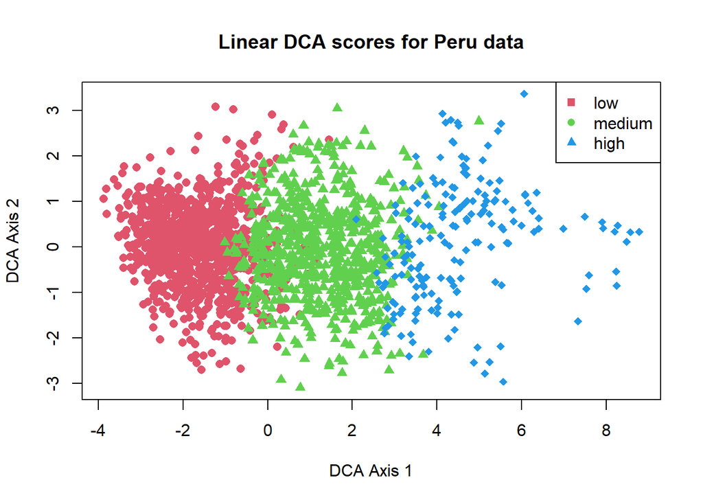

```r
data_da.disc.lda.scale <- lda(scale(data_da[, c(5,6)]), grouping = data_da$hdi_cat)

#Calculate scores
scores <- as.matrix(scale(data_da[,  c(5,6)]))%*%matrix(data_da.disc.lda.scale$scaling, ncol = 2)

#NOTE - if use cross-validation option, scores are calculated automatically
plot(scores[,1], scores[,2], type = "n", main = "Linear DCA scores for Peru data",
     xlab = "DCA Axis 1", ylab = "DCA Axis 2")

data_danames <- levels(data_da$hdi_cat)

for (i in 1:3){
  points(scores[data_da$hdi_cat == data_danames[i], 1],
         scores[data_da$hdi_cat == data_danames[i], 2], col = i+1, pch = 15+i, cex = 1.1)
}
legend("topright", legend = data_danames, col = c(2:4), pch = c(15, 16, 17))
```

It seems that the axis 1 separates the groups very well. These groups are similar in axis 2. The results show what we learn in the class that the first discriminant function is always the ‘best’.

### 7.3.8 Partition plot

I did a partition plot of my data in the space spanned by two of my most important discriminating original variables that show which regions were assigned to each group

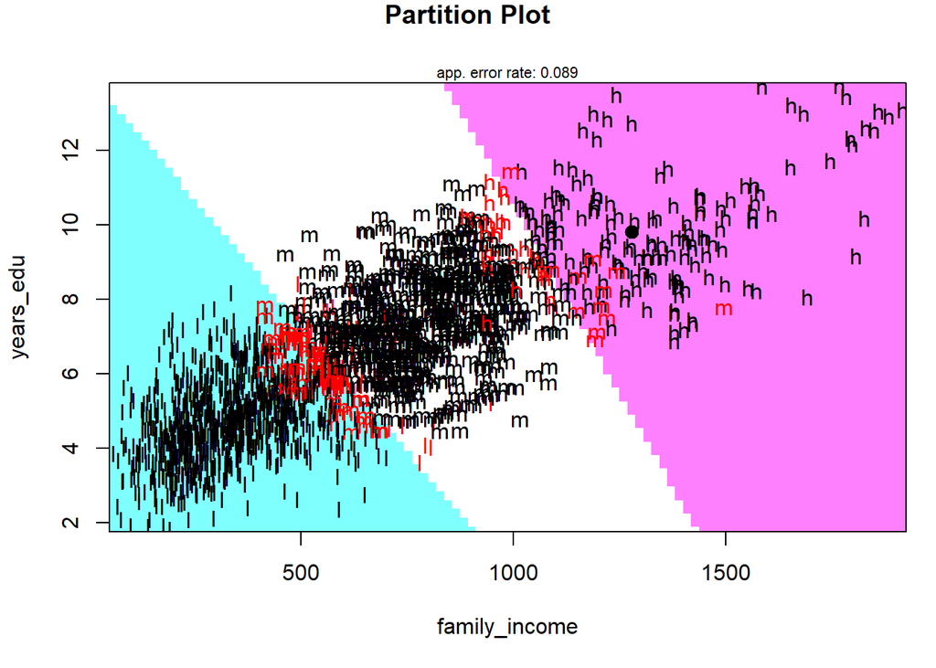

```r
partimat(hdi_cat ~ years_edu + family_income, data = data_da, method = "lda")
```

It seems that the space defined by the two important variables separates the groups very well.

## 7.4 Summary of DA

DA requires multivariate normal distribution within each group. After several attempts in 7.2 part and discussion with Dr. Reuning-Scherer, I decided to only include non-proportion variables (years_edu, life_expectancy and family_income) in the DA to meet the assumption of DA. According to the characteristic of my data, linear DA is better to be used.

From stepwise discriminant analysis, there is only 1 variable (family outcome) retained, I add another (years_edu) in the lda according to Dr. Reuning-Scherer’s suggestion. The DA functions based on family outcome and years_edu work very well in separating the groups of different HDI level. The variables have a 91% correct percent for prediction.

# 8. Multivariate analysis 3: MANOVA

## 8.1 Data wrangling

For the purpose of two-way MANOVA, I create two categorical variables: (1)hdi_cat: based on Human development index (HDI): HDI of less than 0.400 for low human development, 0.400–0.599 for medium human development, 0.600 or greater for high human development. The purpose of this category is to measure the relative development level within the country, so the category is based on the hdi within Peru and it is different from the HDI category criteria by UNDP. This variable is the same as what I used in discriminant analysis. (2)complete_secondary_edu_cat: based on complete_secondary_edu: low: < 40% of people complete secondary education; medium: 40% to <70% of people complete secondary education; high: >=70% of people complete secondary education. As complete_secondary_edu is very relevant to years_edu and may compete in the model, I remove years_edu.

**I will use monetary_poverty, life_expectancy and family_income as response variables for the MANOVA from 8.2 to 8.4, and reserve hh_1_nbi_or_more and hh_wo_sanitation for additional predicting variables to be added in the model in 8.5.**

```r
data1 <- read.csv('data/data_census.csv')

data_manova <- data1 %>% mutate(hh_1_nbi_or_more = hh_1_nbi_or_more/number_hh,
                          hh_wo_sanitation = hh_wo_sanitation/number_hh,
                          hdi_cat = case_when(idh <0.400 ~ "low HDI",
                                              idh >=0.400 & idh <0.600 ~
                                                'medium HDI',
                                              idh >=0.600 ~ 'high HDI'),
                          hdi_cat = fct_relevel(hdi_cat, "low HDI",
                                                "medium HDI", "high HDI"),
                          complete_secondary_edu_cat = case_when(
                            complete_secondary_edu <0.4 ~ "low EDU",
                            complete_secondary_edu >=0.4 &
                              complete_secondary_edu <0.7 ~ 'medium EDU',
                            complete_secondary_edu >=0.7 ~ 'high EDU'),
                          complete_secondary_edu_cat =
                            fct_relevel(complete_secondary_edu_cat,
                                        "low EDU",
                                        "medium EDU",
                                        "high EDU" )) %>%
dplyr::select(-number_hh, -complete_secondary_edu, -idh, -years_edu)
```

monetary_poverty, life_expectancy and family_income are in different scales, I consulted with Dr. Reuning-Scherer and got information that it was not necessary to convert the data to be in the same scale, as the conversion will not change the result. So I did not change the scale of the data.

## 8.2 Interaction plots

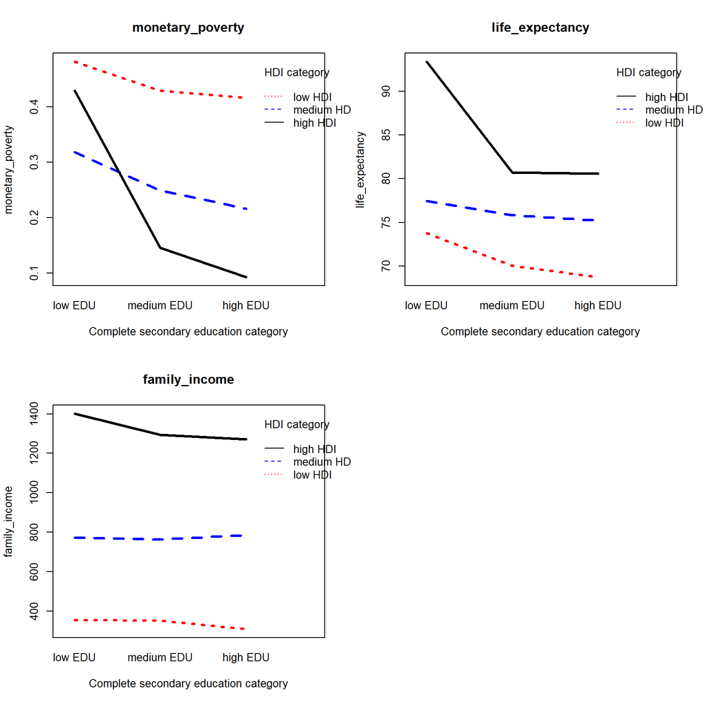

```r
par(mfrow = c(2, 2))

interaction.plot(data_manova$complete_secondary_edu_cat,
                 data_manova$hdi_cat, data_manova$monetary_poverty,
                 lwd = 3, col = c("red", "blue", "black"),
                 trace.label = "HDI category",
                 xlab = "Complete secondary education category",
                 ylab = "monetary_poverty",
                 main = "monetary_poverty")

interaction.plot(data_manova$complete_secondary_edu_cat,
                 data_manova$hdi_cat, data_manova$life_expectancy,
                 lwd = 3, col = c("red", "blue", "black"),
                 trace.label = "HDI category",
                 xlab = "Complete secondary education category",
                 ylab = "life_expectancy",
                 main = "life_expectancy")

interaction.plot(data_manova$complete_secondary_edu_cat,
                 data_manova$hdi_cat, data_manova$family_income,
                 lwd = 3, col = c("red", "blue", "black"),
                 trace.label = "HDI category",
                 xlab = "Complete secondary education category",
                  ylab = "family_income",
                 main = "family_income")
par(mfrow = c(1, 1))
```

In the first plot for monetary_poverty, the lines at low HDI level and medium HDI level are almost parallel to each other, while the high HDI line shows a different pattern. Therefore, there might be some interactions between the HDI category and Complete secondary education category’s effects on monetary_poverty, and the interaction mainly happens at the high HDI level. Specifically, the low EDU & high HDI group has higher poverty proportion than expected.

In the second plot for life_expectancy, the lines at low HDI level and medium HDI level are almost parallel to each other, while the high HDI line shows a different pattern. Therefore, there might be some interactions between the HDI category and Complete secondary education category’s effects on life_expectancy, and the interaction also mainly happens at the high HDI level. Specifically, the low EDU & high HDI group has higher life expectancy than expected.

In the third plot for family_income, the lines at low HDI level, medium HDI level and high HDI level are almost all parallel to each other. Therefore, it seems that there is minimal to no interaction between the HDI category and Complete secondary education category’s effects on family_income.

## 8.3 Two-Way MANOVA

As there are regression formulas in this part. I include codes here.

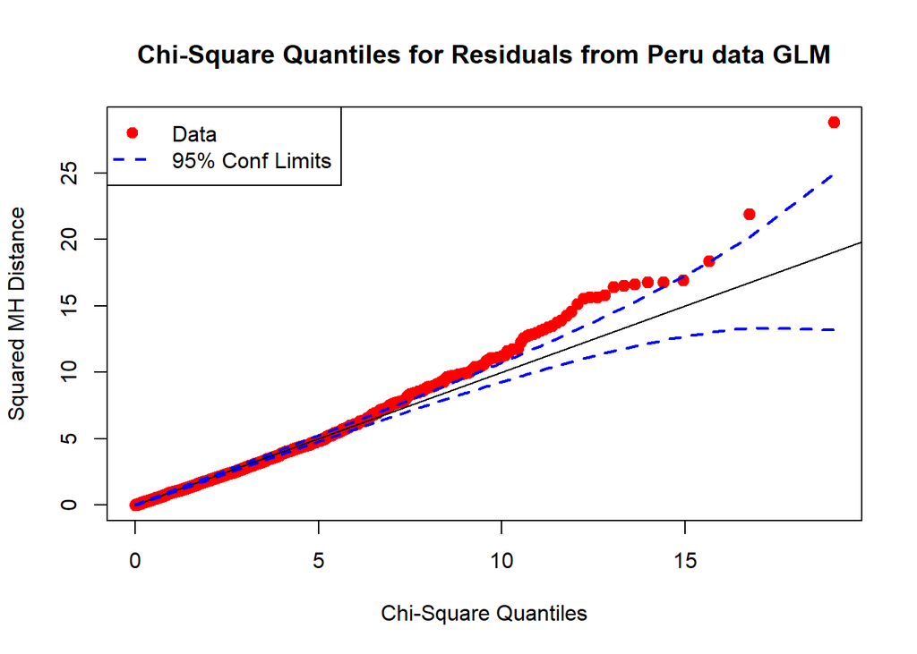

```r
source("http://www.reuningscherer.net/Multivariate/R/CSQPlot.r.txt")

options(contrasts = c("contr.sum", "contr.poly"))
### Default is: options(contrasts = c("contr.treatment", "contr.poly"))


manova1 <- lm(cbind(monetary_poverty, life_expectancy, family_income) ~
                complete_secondary_edu_cat*hdi_cat,
              data = data_manova)

# check our residuals
CSQPlot(manova1$residuals, label = "Residuals from Peru data GLM")
```

Then I conducted both multivariate and univariate analyses as follows:

```r
#Multivariate results and univariate results with type 3 Sum of squares
summary(Anova(manova1, type = 3), univariate = T)
```

```
##
## Type III MANOVA Tests:
##
## Sum of squares and products for error:
##                  monetary_poverty life_expectancy family_income
## monetary_poverty         24.63167        44.28724     -10890.14
## life_expectancy          44.28724    107069.89423    -129067.17
## family_income        -10890.13585   -129067.17411   47613484.85
##
## ------------------------------------------
##
## Term: (Intercept)
##
## Sum of squares and products for the hypothesis:
##                  monetary_poverty life_expectancy family_income
## monetary_poverty         7.070115        1771.119      18588.98
## life_expectancy       1771.119082      443679.181    4656685.51
## family_income        18588.982562     4656685.508   48874774.49
##
## Multivariate Tests: (Intercept)
##                  Df test stat approx F num Df den Df     Pr(>F)
## Pillai            1  0.861240 3854.365      3   1863 < 2.22e-16 ***
## Wilks             1  0.138760 3854.365      3   1863 < 2.22e-16 ***
## Hotelling-Lawley  1  6.206707 3854.365      3   1863 < 2.22e-16 ***
## Roy               1  6.206707 3854.365      3   1863 < 2.22e-16 ***
## ---
## Signif. codes:  0 '***' 0.001 '**' 0.01 '*' 0.05 '.' 0.1 ' ' 1
##
## ------------------------------------------
##
## Term: complete_secondary_edu_cat
##
## Sum of squares and products for the hypothesis:
##                  monetary_poverty life_expectancy family_income
## monetary_poverty        0.3603962        11.47694      130.2871
## life_expectancy        11.4769440       410.11860     3932.4024
## family_income         130.2870930      3932.40243    48151.7203
##
## Multivariate Tests: complete_secondary_edu_cat
##                  Df test stat  approx F num Df den Df     Pr(>F)
```

[output cut: 67 more lines]

```
## complete_secondary_edu_cat                  0.94
## hdi_cat                                  1267.88
## complete_secondary_edu_cat:hdi_cat          1.73
##
##  p-values
##                                    monetary_poverty life_expectancy
## (Intercept)                        < 2.22e-16       < 2.22e-16
## complete_secondary_edu_cat         1.8936e-05       0.0075885
## hdi_cat                            < 2.22e-16       < 2.22e-16
## complete_secondary_edu_cat:hdi_cat 0.0219164        0.1329600
##                                    family_income
## (Intercept)                        < 2.22e-16
## complete_secondary_edu_cat         0.3896273
## hdi_cat                            < 2.22e-16
## complete_secondary_edu_cat:hdi_cat 0.1398680
```

```r
#To get univariate results with Type I Sum of Squares (sequential), I fit a separate model for each response.
mod1 <- lm(monetary_poverty ~ complete_secondary_edu_cat*hdi_cat, data = data_manova)
mod2 <- lm(life_expectancy ~ complete_secondary_edu_cat*hdi_cat, data = data_manova)
mod3 <- lm(family_income ~ complete_secondary_edu_cat*hdi_cat, data = data_manova)

#Type I Sum of Squares
summary.aov(mod1)
```

```
##                                      Df Sum Sq Mean Sq F value Pr(>F)
## complete_secondary_edu_cat            2 13.585   6.793 514.301 <2e-16 ***
## hdi_cat                               2 15.207   7.604 575.715 <2e-16 ***
## complete_secondary_edu_cat:hdi_cat    4  0.101   0.025   1.914  0.105
## Residuals                          1865 24.632   0.013
## ---
## Signif. codes:  0 '***' 0.001 '**' 0.01 '*' 0.05 '.' 0.1 ' ' 1
```

```r
summary.aov(mod2)
```

```
##                                      Df Sum Sq Mean Sq F value   Pr(>F)
## complete_secondary_edu_cat            2   3043    1522   26.50 4.47e-12 ***
## hdi_cat                               2  18225    9113  158.73  < 2e-16 ***
## complete_secondary_edu_cat:hdi_cat    4    232      58    1.01    0.401
## Residuals                          1865 107070      57
## ---
## Signif. codes:  0 '***' 0.001 '**' 0.01 '*' 0.05 '.' 0.1 ' ' 1
```

```r
summary.aov(mod3)
```

```
##                                      Df    Sum Sq  Mean Sq  F value Pr(>F)
## complete_secondary_edu_cat            2  50530868 25265434  989.636 <2e-16 ***
## hdi_cat                               2 117707152 58853576 2305.270 <2e-16 ***
## complete_secondary_edu_cat:hdi_cat    4    177046    44262    1.734   0.14
## Residuals                          1865  47613485    25530
## ---
## Signif. codes:  0 '***' 0.001 '**' 0.01 '*' 0.05 '.' 0.1 ' ' 1
```

The significance level I set is 0.05. According to the two-way MANOVA (multivariate result), complete_secondary_edu_cat and hdi_cat both have significant main effects on our response variables, as shown by P < 0.001 in all the different measures (Pillai, Wilks, Hotelling-Lawley, Roy). For the interaction effects, only Roy measure shows significant result (0.02), and all other measures are not significant. Therefore, I do not think there is enough confidence to say that there is a interaction effect between complete_secondary_edu_cat and hdi_cat on our response variables (monetary_poverty, life_expectancy and family_income).

The univariate results are different depending on whether I use Type I sum of squares or Type III sum of squares. If I use Type I sum of squares, both complete_secondary_edu_cat and hdi_cat have significant individual effects on all three response variables in univariate analysis, while the interaction effects in the three univariate analyses are all not significant. If I use Type III sum of squares, the complete_secondary_edu_cat’s main effect lost significance for family_income, which the interaction of complete_secondary_edu_cat and hdi_cat gained siginificance for monetary_poverty. Other results are similar.

## 8.4 Multivariate contrasts

To do contracts I need to convert a two-way problem into a one-way problem, so first I create an interaction variable which has all combinations of complete_secondary_edu_cat and hdi_cat and then run the analysis in different combinations of the two categorical variables.

As there are regression formulas in this part. I also include codes here.

```r
options(contrasts = c("contr.treatment", "contr.poly"))
## First we need to create a interaction variable which has all combinations of complete_secondary_edu_cat and hdi_cat

data_manova$comb_cat <- interaction(data_manova$complete_secondary_edu_cat, data_manova$hdi_cat)
levels(data_manova$comb_cat)
```

```
## [1] "low EDU.low HDI"       "medium EDU.low HDI"    "high EDU.low HDI"
## [4] "low EDU.medium HDI"    "medium EDU.medium HDI" "high EDU.medium HDI"
## [7] "low EDU.high HDI"      "medium EDU.high HDI"   "high EDU.high HDI"
```

```r
# It shows that "low EDU.low HDI" is the reference level
manova2_contrast <- lm(cbind(monetary_poverty, life_expectancy, family_income) ~ comb_cat, data = data_manova)
```

After consulting with Dr. Reuning-Scherer, I only need to give an example for each of the below. Therefore, I showed one example for each of the section below and described the results of other comparisons.

### 8.4.1 Multivariate contrast on the levels of a particular factor

First I do multivariate comparison on the levels of a particular factor: Different levels of HDI and different levels of EDU

```r
#Get multivariate contrast for high HDI vs medium HDI
linearHypothesis(manova2_contrast, "comb_catlow EDU.high HDI + comb_catmedium EDU.high HDI + comb_cathigh EDU.high HDI - comb_cathigh EDU.medium HDI - comb_catmedium EDU.medium HDI - comb_catlow EDU.medium HDI= 0")
```

```
##
## Sum of squares and products for the hypothesis:
##                  monetary_poverty life_expectancy family_income
## monetary_poverty       0.01264003       -2.850602     -178.9175
## life_expectancy       -2.85060246      642.873225    40349.8170
## family_income       -178.91752682    40349.817021  2532548.6734
##
## Sum of squares and products for error:
##                  monetary_poverty life_expectancy family_income
## monetary_poverty         24.63167        44.28724     -10890.14
## life_expectancy          44.28724    107069.89423    -129067.17
## family_income        -10890.13585   -129067.17411   47613484.85
##
## Multivariate Tests:
##                  Df test stat approx F num Df den Df     Pr(>F)
## Pillai            1 0.0603302 39.87046      3   1863 < 2.22e-16 ***
## Wilks             1 0.9396698 39.87046      3   1863 < 2.22e-16 ***
## Hotelling-Lawley  1 0.0642036 39.87046      3   1863 < 2.22e-16 ***
## Roy               1 0.0642036 39.87046      3   1863 < 2.22e-16 ***
## ---
## Signif. codes:  0 '***' 0.001 '**' 0.01 '*' 0.05 '.' 0.1 ' ' 1
```

The displayed multivariate comparison of high HDI vs medium HDI shows significant difference. I also tried all different categories of HDI and EDU, and found their multivariate comparisons were all significantly different (ie, high HDI vs medium HDI, low HDI vs high HDI, low HDI vs medium HDI, high EDU vs medium EDU, low EDU vs high EDU, low EDU vs medium EDU are all different).

### 8.4.2 Multivariate contrast for high HDI, medium HDI and high EDU, medium EDU interaction

```r
linearHypothesis(manova2_contrast, "comb_cathigh EDU.high HDI + comb_catmedium EDU.high HDI -  comb_cathigh EDU.medium HDI - comb_catmedium EDU.medium HDI= 0")
```

```
##
## Sum of squares and products for the hypothesis:
##                  monetary_poverty life_expectancy family_income
## monetary_poverty         1.480133       -66.79605     -6627.616
## life_expectancy        -66.796053      3014.40046    299093.846
## family_income        -6627.615944    299093.84644  29676590.804
##
## Sum of squares and products for error:
##                  monetary_poverty life_expectancy family_income
## monetary_poverty         24.63167        44.28724     -10890.14
## life_expectancy          44.28724    107069.89423    -129067.17
## family_income        -10890.13585   -129067.17411   47613484.85
##
## Multivariate Tests:
##                  Df test stat approx F num Df den Df     Pr(>F)
## Pillai            1 0.4007606 415.3137      3   1863 < 2.22e-16 ***
## Wilks             1 0.5992394 415.3137      3   1863 < 2.22e-16 ***
## Hotelling-Lawley  1 0.6687822 415.3137      3   1863 < 2.22e-16 ***
## Roy               1 0.6687822 415.3137      3   1863 < 2.22e-16 ***
## ---
## Signif. codes:  0 '***' 0.001 '**' 0.01 '*' 0.05 '.' 0.1 ' ' 1
```

There is significant interaction between the effect of high HDI, medium HDI and high EDU, medium EDU in multivariate comparison. I also tried other combinations of interaction effects, and most of them were significant.

## 8.5 Add a continuous variable to my model and fit as a multiple-response linear model

As can be seen from the correlation plot below, the association of hh_wo_sanitation and hh_1_nbi_or_more, and the 3 response variables is weakly linear. I discussed with Dr. Reuning-Scherer and he considered such relationship is acceptable to be added to the model. It seems that hh_wo_sanitation has a relatively more linear relationship with the three response variables. So I add hh_wo_sanitation to the model.

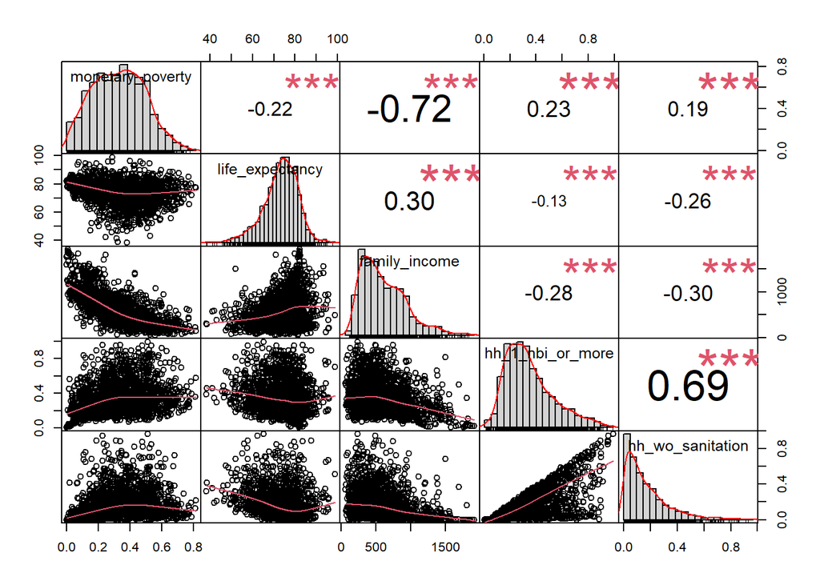

```r
# Distribution between the potential new predicting variables and response variables
chart.Correlation(data_manova[, c('monetary_poverty', 'life_expectancy', 'family_income', 'hh_1_nbi_or_more', 'hh_wo_sanitation')])
```

```r
manova_add <- lm(cbind(monetary_poverty, life_expectancy, family_income) ~ complete_secondary_edu_cat*hdi_cat + hh_wo_sanitation,
                 data = data_manova)
summary(Anova(manova_add, type = 3), univariate = T)
```

```
##
## Type III MANOVA Tests:
##
## Sum of squares and products for error:
##                  monetary_poverty life_expectancy family_income
## monetary_poverty         24.62039        38.16846     -10960.08
## life_expectancy          38.16846    103750.54544    -167012.07
## family_income        -10960.08228   -167012.07382   47179720.42
##
## ------------------------------------------
##
## Term: (Intercept)
##
## Sum of squares and products for the hypothesis:
##                  monetary_poverty life_expectancy family_income
## monetary_poverty         65.69526        10237.62       50685.1
## life_expectancy       10237.61581      1595378.07     7898508.4
## family_income         50685.09848      7898508.40    39104483.3
##
## Multivariate Tests: (Intercept)
##                  Df test stat approx F num Df den Df     Pr(>F)
## Pillai            1  0.954517 13025.39      3   1862 < 2.22e-16 ***
## Wilks             1  0.045483 13025.39      3   1862 < 2.22e-16 ***
## Hotelling-Lawley  1 20.986133 13025.39      3   1862 < 2.22e-16 ***
## Roy               1 20.986133 13025.39      3   1862 < 2.22e-16 ***
## ---
## Signif. codes:  0 '***' 0.001 '**' 0.01 '*' 0.05 '.' 0.1 ' ' 1
##
## ------------------------------------------
##
## Term: complete_secondary_edu_cat
##
## Sum of squares and products for the hypothesis:
##                  monetary_poverty life_expectancy family_income
## monetary_poverty        0.6640113        47.25026      91.76748
## life_expectancy        47.2502612      3369.44714    7273.81751
## family_income          91.7674817      7273.81751   89784.44261
##
## Multivariate Tests: complete_secondary_edu_cat
##                  Df test stat approx F num Df den Df     Pr(>F)
```

[output cut: 92 more lines]

```
## complete_secondary_edu_cat:hdi_cat          1.96
##
##  p-values
##                                    monetary_poverty life_expectancy
## (Intercept)                        < 2.22e-16       < 2.22e-16
## complete_secondary_edu_cat         1.8921e-12       3.5106e-12
## hdi_cat                            2.1650e-13       0.00057338
## hh_wo_sanitation                   0.93103707       1.8494e-14
## complete_secondary_edu_cat:hdi_cat 0.01859468       0.05978084
##                                    family_income
## (Intercept)                        < 2.22e-16
## complete_secondary_edu_cat         0.05979983
## hdi_cat                            < 2.22e-16
## hh_wo_sanitation                   0.00019755
## complete_secondary_edu_cat:hdi_cat 0.09816753
```

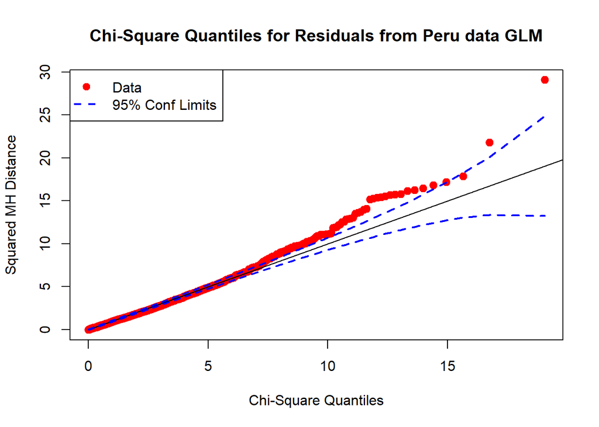

```r
#check our residuals
CSQPlot(manova_add$residuals, label = "Residuals from Peru data GLM")
```

In the new MANOVA model, complete_secondary_edu_cat and hdi_cat also have significant main effects on the response variables. In previous model (manova1), complete_secondary_edu_cat and hdi_cat do not have significant interaction effect, while now, in the new model, they have a significant interaction effect!

## 8.6 MRPP test

```r
(mrpp1 <- mrpp(data_manova[,c("monetary_poverty", "life_expectancy",
                        "family_income")], data_manova$hdi_cat))
```

```
##
## Call:
## mrpp(dat = data_manova[, c("monetary_poverty", "life_expectancy",      "family_income")], grouping = data_manova$hdi_cat)
##
## Dissimilarity index: euclidean
## Weights for groups:  n
##
## Class means and counts:
##
##       low HDI medium HDI high HDI
## delta 158.9   184.8      265.9
## n     1018    670        186
##
## Chance corrected within-group agreement A: 0.5223
## Based on observed delta 178.8 and expected delta 374.3
##
## Significance of delta: 0.001
## Permutation: free
## Number of permutations: 999
```

```r
(mrpp2 <- mrpp(data_manova[,c("monetary_poverty", "life_expectancy",
                        "family_income")], data_manova$complete_secondary_edu_cat))
```

```
##
## Call:
## mrpp(dat = data_manova[, c("monetary_poverty", "life_expectancy",      "family_income")], grouping = data_manova$complete_secondary_edu_cat)
##
## Dissimilarity index: euclidean
## Weights for groups:  n
##
## Class means and counts:
##
##       low EDU medium EDU high EDU
## delta 207.2   333.3      434.9
## n     404     1129       341
##
## Chance corrected within-group agreement A: 0.1327
## Based on observed delta 324.6 and expected delta 374.3
##
## Significance of delta: 0.001
## Permutation: free
## Number of permutations: 999
```

```r
(mrpp3 <- mrpp(data_manova[,c("monetary_poverty", "life_expectancy",
                        "family_income")], data_manova$comb_cat))
```

```
##
## Call:
## mrpp(dat = data_manova[, c("monetary_poverty", "life_expectancy",      "family_income")], grouping = data_manova$comb_cat)
##
## Dissimilarity index: euclidean
## Weights for groups:  n
##
## Class means and counts:
##
##       low EDU.low HDI medium EDU.low HDI high EDU.low HDI low EDU.medium HDI
## delta 165.5           157.8              113.9            143.1
## n     371             598                49               32
##       medium EDU.medium HDI high EDU.medium HDI low EDU.high HDI
## delta 188.1                 179.9                 NaN
## n     478                   160                 1
##       medium EDU.high HDI high EDU.high HDI
## delta 220.2               282.8
## n     53                  132
##
## Chance corrected within-group agreement A: 0.524
## Based on observed delta 178.1 and expected delta 374.3
##
## Significance of delta: 0.001
## Permutation: free
## Number of permutations: 999
```

The MRPP tests seem to be all significant above (different HDI categories, different EDU categories, and different combinations of the two categories).

## 8.7 Summary of MANOVA

In this part, I first investigated the potential interaction of the two categorical variables on the 3 continuous variables by doing interaction plots. And the plots showed that there might be some interaction effects on monetary_poverty and life_expectancy, but the interaction is minimal on family_income.

Then I did two-way ANOVA with monetary_poverty, life_expectancy and family_income as response variables and hdi_cat (HDI category) and complete_secondary_edu_cat (Education category) as categorical predicting variables. According to the two-way MANOVA (multivariate result), complete_secondary_edu_cat and hdi_cat both have significant main effects on our response variables, as shown by P < 0.001 in all the different measures (Pillai, Wilks, Hotelling-Lawley, Roy). However, there is not strong evidence of an interaction effect between complete_secondary_edu_cat and hdi_cat on the response variables. The univariate results varied by whether Type I sum of squares or Type III sum of squares was used.

Next, I tried multivariate and univariate contrasts, which again supported the difference in different levels of HDI and education. Then I tried to add a continuous variable to the manova model to make it multiple response linear model. The main effects and interaction effect of the two categorical variables are both significant in the new model.I also tried MRPP test, which showed different multivariate means in HDI categories, education categories, combinations of the two categories.

In summary, there is strong evidence that the multivariate means of different HDI categories and education categories are different. Whether there is significant interaction effect of the two categorical variables depends on the models and methods.

# 9. Multivariate analysis 4: Cluster analysis with variables

## 9.1 Data wrangling

As my variables are at different scales (money, proportion, year, etc.), for the purpose of cluster analysis, it will be necessary to standardize the data or else the distance cannot be correctly measured. Therefore, I standardized the data.

```r
data_cs <- data1[,-1]
rownames(data_cs) <- data1[, 1]
data_cs <- scale(na.omit(data_cs))
```

## 9.2 Hierarchical cluster analysis with different distance metrics and agglomeration methods

It is meaningful to cluster the variables to see how the variables move together.

The variables I plan to include in the cluster analysis are all continuous variables. I think Euclidean distance is the most appropriate distance, but Manhattan distance and maximum distrance may also work. So I will give them a try in later analyses.

As my variables are at different scales (money, proportion, year, etc.) It will be necessary to standardize the data or else the distance cannot be correctly measured, and some variables will have higher influence on the distance than other variables. I have standardized the data in the data wrangling stage above.

### 9.2.1 cluster the variables

The figures below are k = 4 and k = 2 results of Euclidean distance with average linkage:

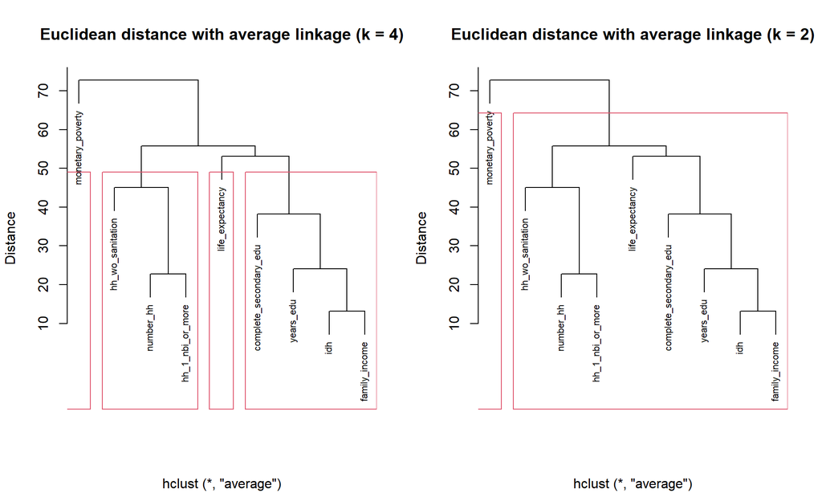

```r
data_cs_t <- t(data_cs)
# 2.1.1 Euclidean distance with average linkage----
dist1 <- dist(data_cs_t, method = "euclidean")

clust1 <- hclust(dist1, method = "average")

par(mfrow = c(1, 2))
plot(clust1, labels = names(data_cs_t), cex = 0.7, xlab = "", ylab = "Distance", main = "Euclidean distance with average linkage (k = 4)")
rect.hclust(clust1, k = 4)

plot(clust1, labels = names(data_cs_t), cex = 0.7, xlab = "", ylab = "Distance", main = "Euclidean distance with average linkage (k = 2)")
rect.hclust(clust1, k = 2)
```

Then I tried different combinations of distance and linkage methods for k = 4:

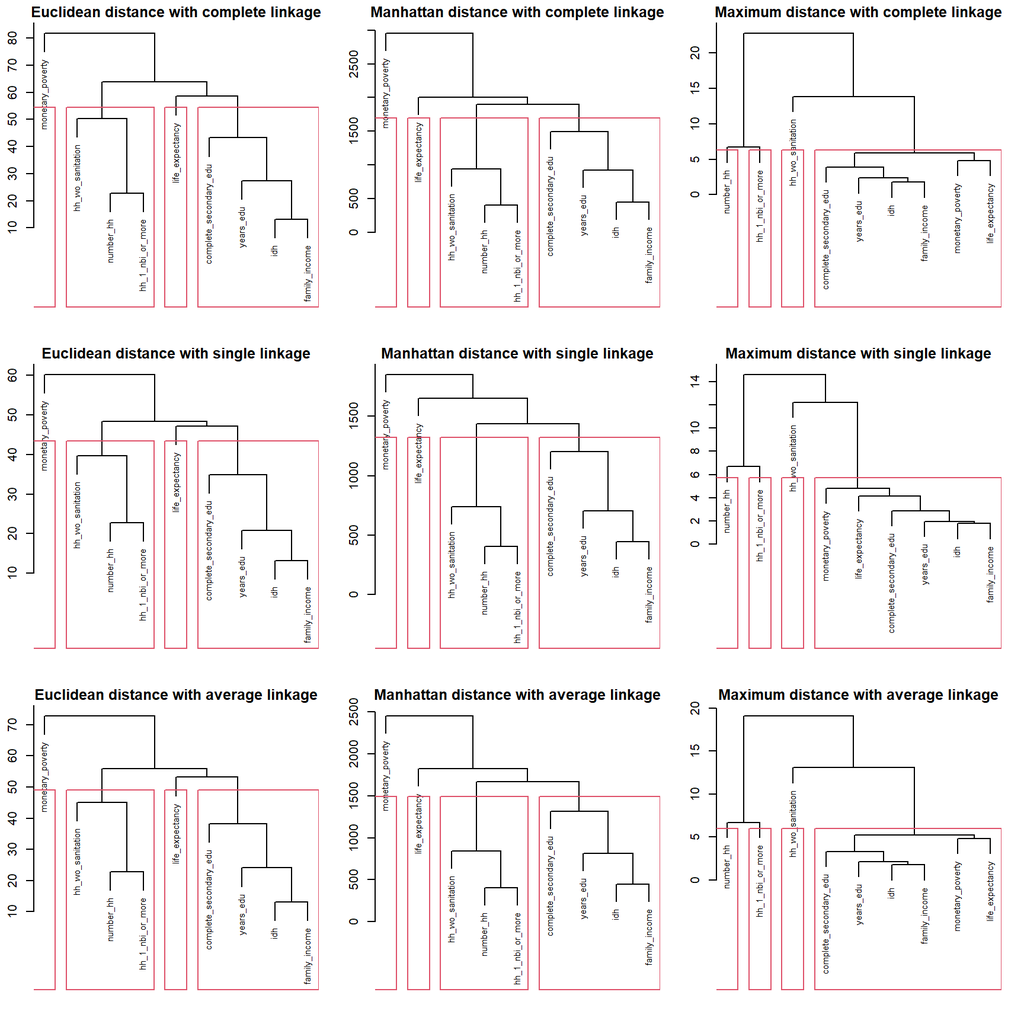

```r
data_cs_t <- t(data_cs)
# 2.1.1 Euclidean distance with complete linkage----
dist1 <- dist(data_cs_t, method = "euclidean")

clust1 <- hclust(dist1, method = "complete")

# 2.1.2 Manhattan distance with complete linkage----

dist2 <- dist(data_cs_t, method = "manhattan")

clust2 <- hclust(dist2, method = "complete")

# 2.1.3 Maximum distance with complete linkage----
dist3 <- dist(data_cs_t, method = "maximum")

clust3 <- hclust(dist3, method = "complete")

# 2.1.4 Euclidean distance with single linkage----
dist4 <- dist(data_cs_t, method = "euclidean")

clust4 <- hclust(dist4, method = "single")


# 2.1.5 Manhattan distance with single linkage----
dist5 <- dist(data_cs_t, method = "manhattan")

clust5 <- hclust(dist5, method = "single")

# 2.1.6 Maximum distance with single linkage----
dist6 <- dist(data_cs_t, method = "maximum")

clust6 <- hclust(dist6, method = "single")

# 2.1.7 Euclidean distance with average linkage----
dist7 <- dist(data_cs_t, method = "euclidean")

clust7 <- hclust(dist7, method = "average")

# 2.1.8 Manhattan distance with average linkage----
dist8 <- dist(data_cs_t, method = "manhattan")

clust8 <- hclust(dist8, method = "average")

# 2.1.9 Maximum distance with average linkage----
dist9 <- dist(data_cs_t, method = "maximum")

clust9 <- hclust(dist9, method = "average")

# 2.1.10 combine figure k = 4 (9 plots)----
par(oma = c(0, 0, 0, 0))
par(mai = c(0.3, 0.3, 0.2, 0.2))
par(mfrow = c(3, 3))
plot(clust1, labels = names(data_cs_t), cex = 0.7, xlab = "", ylab = "Distance", main = "Euclidean distance with complete linkage")
rect.hclust(clust1, k = 4)

plot(clust2, labels = names(data_cs_t), cex = 0.7, xlab = "", ylab = "Distance", main = "Manhattan distance with complete linkage")
rect.hclust(clust2, k = 4)

plot(clust3, labels = names(data_cs_t), cex = 0.7, xlab = "", ylab = "Distance", main = "Maximum distance with complete linkage")
rect.hclust(clust3, k = 4)

plot(clust4, labels = names(data_cs_t), cex = 0.7, xlab = "", ylab = "Distance", main = "Euclidean distance with single linkage")
rect.hclust(clust4, k = 4)

plot(clust5, labels = names(data_cs_t), cex = 0.7, xlab = "", ylab = "Distance", main = "Manhattan distance with single linkage")
rect.hclust(clust5, k = 4)

plot(clust6, labels = names(data_cs_t), cex = 0.7, xlab = "", ylab = "Distance", main = "Maximum distance with single linkage")
rect.hclust(clust6, k = 4)

plot(clust7, labels = names(data_cs_t), cex = 0.7, xlab = "", ylab = "Distance", main = "Euclidean distance with average linkage")
rect.hclust(clust7, k = 4)

plot(clust8, labels = names(data_cs_t), cex = 0.7, xlab = "", ylab = "Distance", main = "Manhattan distance with average linkage")
rect.hclust(clust8, k = 4)

plot(clust9, labels = names(data_cs_t), cex = 0.7, xlab = "", ylab = "Distance", main = "Maximum distance with average linkage")
rect.hclust(clust9, k = 4)
```

I also tried different combinations of distance and linkage methods for k = 2:

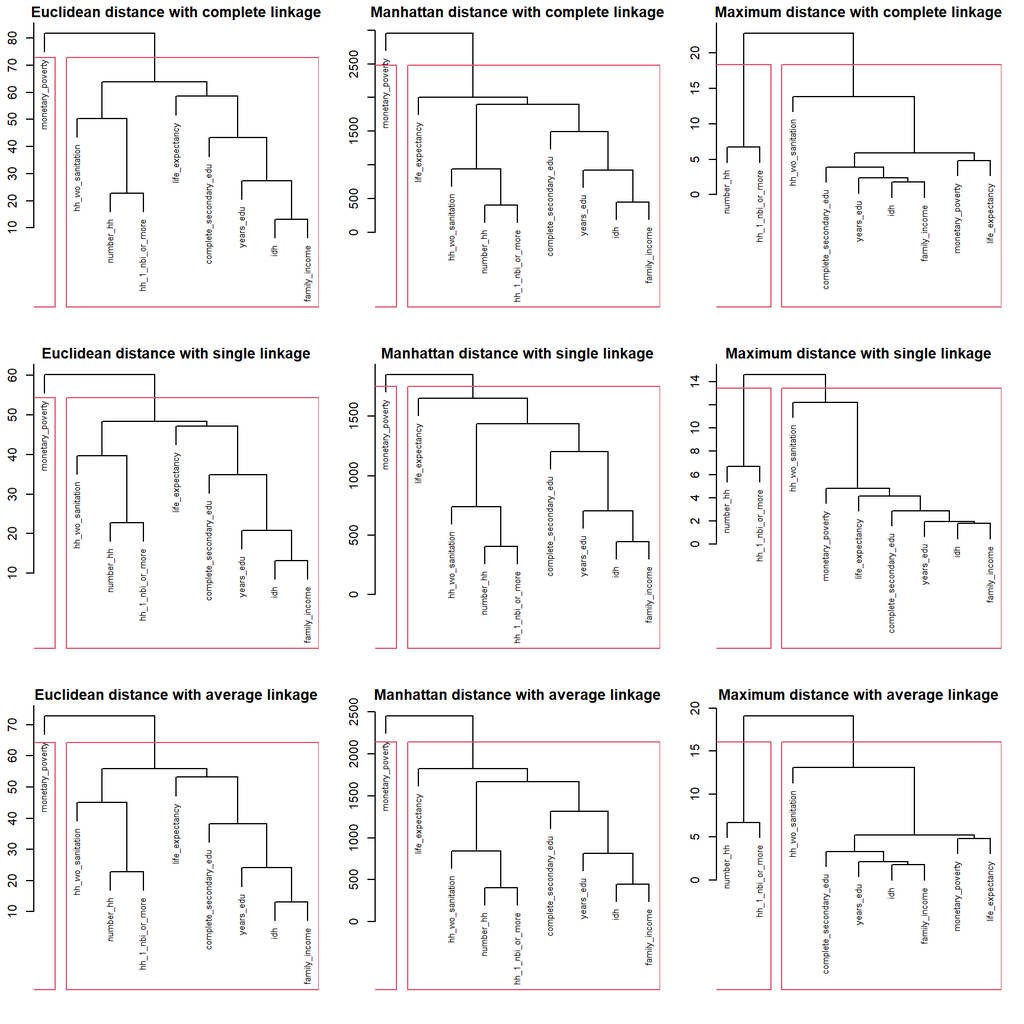

```r
# 2.1.11 combine figure k = 2 (9 plots)----
par(oma = c(0, 0, 0, 0))

par(mai = c(0.3, 0.3, 0.2, 0.2))

par(mfrow = c(3, 3))

plot(clust1, labels = names(data_cs_t), cex = 0.7, xlab = "", ylab = "Distance", main = "Euclidean distance with complete linkage")
rect.hclust(clust1, k = 2)

plot(clust2, labels = names(data_cs_t), cex = 0.7, xlab = "", ylab = "Distance", main = "Manhattan distance with complete linkage")
rect.hclust(clust2, k = 2)

plot(clust3, labels = names(data_cs_t), cex = 0.7, xlab = "", ylab = "Distance", main = "Maximum distance with complete linkage")
rect.hclust(clust3, k = 2)

plot(clust4, labels = names(data_cs_t), cex = 0.7, xlab = "", ylab = "Distance", main = "Euclidean distance with single linkage")
rect.hclust(clust4, k = 2)

plot(clust5, labels = names(data_cs_t), cex = 0.7, xlab = "", ylab = "Distance", main = "Manhattan distance with single linkage")
rect.hclust(clust5, k = 2)

plot(clust6, labels = names(data_cs_t), cex = 0.7, xlab = "", ylab = "Distance", main = "Maximum distance with single linkage")
rect.hclust(clust6, k = 2)

plot(clust7, labels = names(data_cs_t), cex = 0.7, xlab = "", ylab = "Distance", main = "Euclidean distance with average linkage")
rect.hclust(clust7, k = 2)

plot(clust8, labels = names(data_cs_t), cex = 0.7, xlab = "", ylab = "Distance", main = "Manhattan distance with average linkage")
rect.hclust(clust8, k = 2)

plot(clust9, labels = names(data_cs_t), cex = 0.7, xlab = "", ylab = "Distance", main = "Maximum distance with average linkage")
rect.hclust(clust9, k = 2)
```

```r
par(mfrow = c(1, 1), oma = c(0, 0, 0, 0), mai = c(1, 1, 1, 1))
```

To sum up, different distance and agglomeration methods seem to perform equally well in the variables of my data.

### 9.2.2 Group diagnostic function: cluster variables

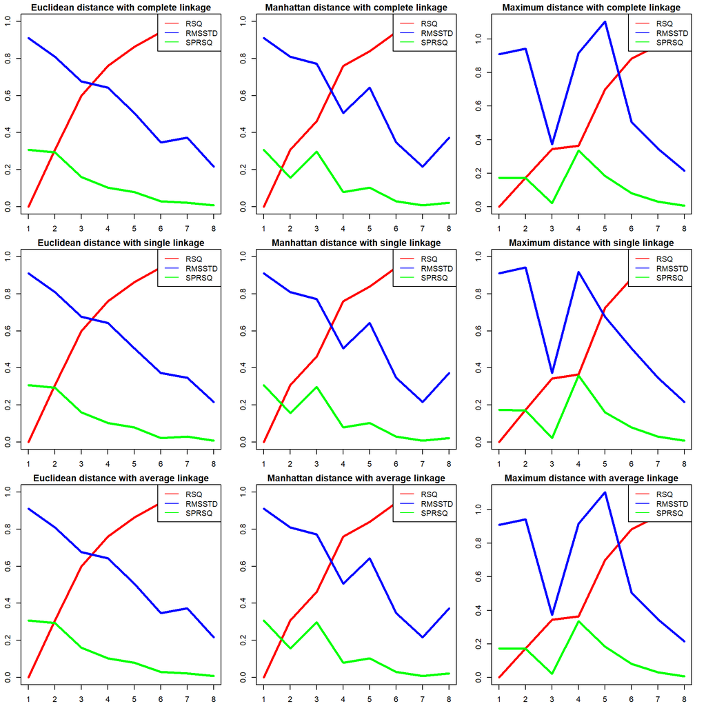

```r
source("http://reuningscherer.net/multivariate/R/HClusEval3.R.txt")

hclus_eval <- function(data_m, dist_m = 'euclidean', clus_m = 'ward', plot_op = T, dist_cust = NA, print_num = NA, title){

  output_list <- list()

  ## Some Initial Calculations

 ### END INITIAL CALCULATIONS

  ### Create Distance matrix and Clustering ###
  Info <- paste('Creating Distance Matrix using', dist_m)
 # print(Info)

    if (dist_m == 'custom' & !is.na(dist_cust)) {dist1 <- dist_cust}
    else dist1 <- dist(data_m, method= dist_m)


  Info <- paste('Clustering using', clus_m)
#  print(Info)

  clust1 <- hclust(dist1, method = clus_m)

#  print('Clustering Complete. Access the Cluster object in first element of output')

  output_list[[1]] <- clust1


  rs_out <- affected.rows(clust1$merge)

  me <- gen_cutmat(clust1, dim(data_m)[1])
  rs <- rs_out[[2]]

  # Calculate Metrics #

  output_list[[2]] <- RMSSTD_FUNC(data_m, rs, dim(data_m)[1])

  output_list[[3]] <- RSQ_FUNC(data_m, me, dim(data_m)[1])

  output_list[[4]] <- SPRS_FUNC(data_m, rs, dim(data_m)[1], me)

  output_list[[5]] <- cluster.dis(data_m, clust1, output_list[[4]])

  #ylim_n <- max(output_list[[2]], output_list[[3]], output_list[[4]], output_list[[5]])
  ylim_n <- max(output_list[[2]], output_list[[3]], output_list[[4]])

  if (plot_op == T){
    print_len <- rep(print_num, 5)
    if (is.na(print_num)) {
       for (i in 1:5) {print_len[i] <- length(output_list[[i]])}
    }
    plot(output_list[[3]][1:print_len[3]], type = 'l', col = 'red', ylim = c(0, ylim_n), lwd=3, main = title)
    lines(output_list[[2]][1:print_len[2]], col = 'blue', lwd=3)
    lines(output_list[[4]][1:print_len[4]], col = 'green', lwd=3)
    #lines(output_list[[5]][1:print_len[5]], col = 'black', lwd=3)
    legend('topright', c('RSQ', 'RMSSTD', 'SPRSQ'), lty = c(1 ,1,1),
      col = c('red', 'blue', 'green'))
    #Plot CD


  }



}

par(oma = c(0, 0, 0, 0))

par(mai = c(0.3, 0.3, 0.2, 0.2))

par(mfrow = c(3, 3))
#Call the function
hclus_eval(data_cs_t, dist_m = 'euclidean', clus_m = 'complete', plot_op = T, print_num = 8,
           title = "Euclidean distance with complete linkage")

hclus_eval(data_cs_t, dist_m = 'manhattan', clus_m = 'complete', plot_op = T, print_num = 8,
           title = "Manhattan distance with complete linkage")

hclus_eval(data_cs_t, dist_m = 'maximum', clus_m = 'complete', plot_op = T, print_num = 8,
           title = "Maximum distance with complete linkage")

hclus_eval(data_cs_t, dist_m = 'euclidean', clus_m = 'single', plot_op = T, print_num = 8,
           title = "Euclidean distance with single linkage")

hclus_eval(data_cs_t, dist_m = 'manhattan', clus_m = 'single', plot_op = T, print_num = 8,
           title = "Manhattan distance with single linkage")

hclus_eval(data_cs_t, dist_m = 'maximum', clus_m = 'single', plot_op = T, print_num = 8,
           title = "Maximum distance with single linkage")

hclus_eval(data_cs_t, dist_m = 'euclidean', clus_m = 'average', plot_op = T, print_num = 8,
           title = "Euclidean distance with average linkage")

hclus_eval(data_cs_t, dist_m = 'manhattan', clus_m = 'average', plot_op = T, print_num = 8,
           title = "Manhattan distance with average linkage")

hclus_eval(data_cs_t, dist_m = 'maximum', clus_m = 'average', plot_op = T, print_num = 8,
           title = "Maximum distance with average linkage")
```

```r
par(mfrow = c(1, 1), oma = c(0, 0, 0, 0), mai = c(1, 1, 1, 1))
```

It seems that 2 or 4 groups are more reasonable in most scenarios.

## 9.3 K-means cluster

### 9.3.1 k-means clustering: pre-defined fixed number of groups

Group number = 2:

```r
km1 <- kmeans(data_cs_t, centers = 2)
#see which countries are in each cluster
for (i in 1:2){
  print(paste("Variables in Cluster ", i))
  print(names(data1)[-1][km1$cluster == i])
  print (" ")
}
```

```
## [1] "Variables in Cluster  1"
## [1] "monetary_poverty" "number_hh"        "hh_1_nbi_or_more" "hh_wo_sanitation"
## [1] " "
## [1] "Variables in Cluster  2"
## [1] "idh"                    "life_expectancy"        "complete_secondary_edu"
## [4] "years_edu"              "family_income"
## [1] " "
```

Group number = 4:

```r
km2 <- kmeans(data_cs_t, centers = 4)
#see which countries are in each cluster
for (i in 1:4){
  print(paste("Variables in Cluster ", i))
  print(names(data1)[-1][km2$cluster == i])
  print (" ")
}
```

```
## [1] "Variables in Cluster  1"
## [1] "monetary_poverty"
## [1] " "
## [1] "Variables in Cluster  2"
## [1] "number_hh"        "hh_1_nbi_or_more"
## [1] " "
## [1] "Variables in Cluster  3"
## [1] "idh"                    "life_expectancy"        "complete_secondary_edu"
## [4] "years_edu"              "family_income"
## [1] " "
## [1] "Variables in Cluster  4"
## [1] "hh_wo_sanitation"
## [1] " "
```

For 4 groups, the k-means cluster method produced slightly different result. Eucidean distance with average linkage and Mahhatan distance with single linkage provided the most close results to k-means

### 9.3.2 k-means clustering: no pre-defined number of groups

Then I apply K-means method without pre-defined fixed number of groups

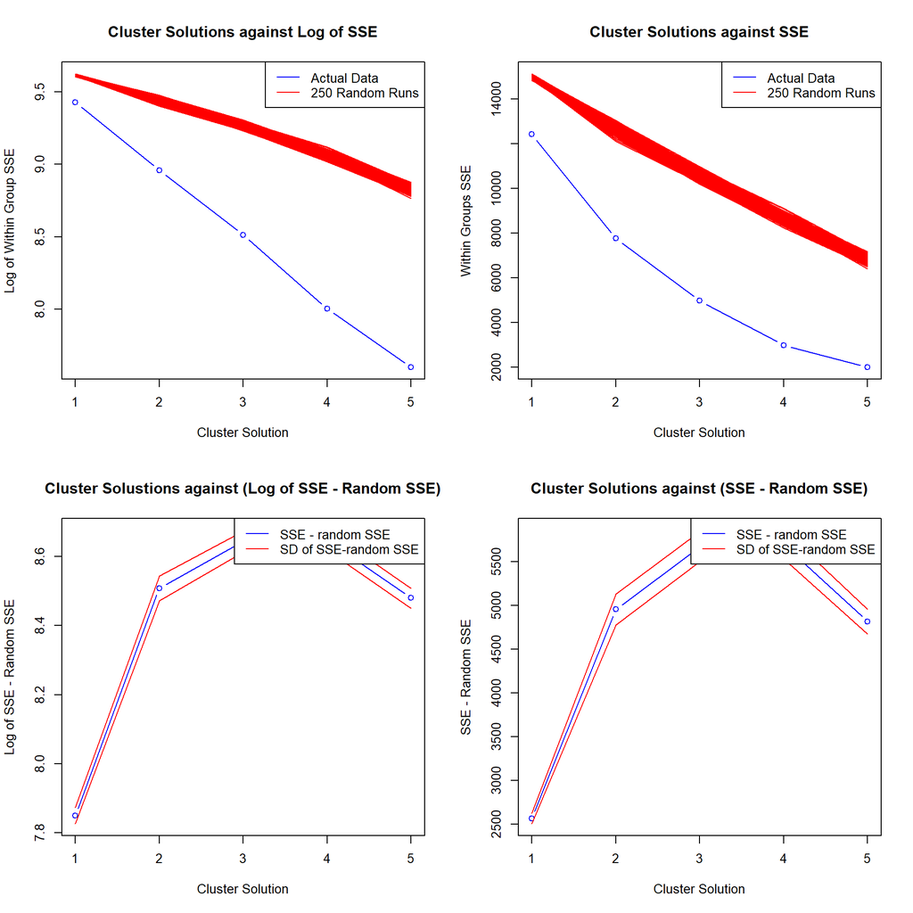

```r
par(mfrow = c(2, 2))

kdata <- data_cs_t
n.lev <- 5  #set max value for number of clusters k

# Calculate the within groups sum of squared error (SSE) for the number of cluster solutions selected by the user
wss <- rnorm(3)
while (prod(wss==sort(wss,decreasing=T))==0) {
  wss <- (nrow(kdata)-1)*sum(apply(kdata,2,var))
  for (i in 2:n.lev) wss[i] <- sum(kmeans(kdata, centers=i)$withinss)}

# Calculate the within groups SSE for 250 randomized data sets (based on the original input data)
k.rand <- function(x){
  km.rand <- matrix(sample(x),dim(x)[1],dim(x)[2])
  rand.wss <- as.matrix(dim(x)[1]-1)*sum(apply(km.rand,2,var))
  for (i in 2:n.lev) rand.wss[i] <- sum(kmeans(km.rand, centers=i)$withinss)
  rand.wss <- as.matrix(rand.wss)
  return(rand.wss)
}

rand.mat <- matrix(0,n.lev,250)

k.1 <- function(x) {
  for (i in 1:250) {
    r.mat <- as.matrix(suppressWarnings(k.rand(kdata)))
    rand.mat[,i] <- r.mat}
  return(rand.mat)
}

# Same function as above for data with < 3 column variables
k.2.rand <- function(x){
  rand.mat <- matrix(0,n.lev,250)
  km.rand <- matrix(sample(x),dim(x)[1],dim(x)[2])
  rand.wss <- as.matrix(dim(x)[1]-1)*sum(apply(km.rand,2,var))
  for (i in 2:n.lev) rand.wss[i] <- sum(kmeans(km.rand, centers=i)$withinss)
  rand.wss <- as.matrix(rand.wss)
  return(rand.wss)
}

k.2 <- function(x){
  for (i in 1:250) {
    r.1 <- k.2.rand(kdata)
    rand.mat[,i] <- r.1}
  return(rand.mat)
}

# Determine if the data data table has > or < 3 variables and call appropriate function above
if (dim(kdata)[2] == 2) { rand.mat <- k.2(kdata) } else { rand.mat <- k.1(kdata) }

# Plot within groups SSE against all tested cluster solutions for actual and randomized data - 1st: Log scale, 2nd: Normal scale

xrange <- range(1:n.lev)
yrange <- range(log(rand.mat),log(wss))
plot(xrange,yrange, type='n', xlab='Cluster Solution', ylab='Log of Within Group SSE', main='Cluster Solutions against Log of SSE')
for (i in 1:250) lines(log(rand.mat[,i]),type='l',col='red')
lines(log(wss), type="b", col='blue')
legend('topright',c('Actual Data', '250 Random Runs'), col=c('blue', 'red'), lty=1)

yrange <- range(rand.mat,wss)
plot(xrange,yrange, type='n', xlab="Cluster Solution", ylab="Within Groups SSE", main="Cluster Solutions against SSE")
for (i in 1:250) lines(rand.mat[,i],type='l',col='red')
lines(1:n.lev, wss, type="b", col='blue')
legend('topright',c('Actual Data', '250 Random Runs'), col=c('blue', 'red'), lty=1)

# Calculate the mean and standard deviation of difference between SSE of actual data and SSE of 250 randomized datasets
r.sse <- matrix(0,dim(rand.mat)[1],dim(rand.mat)[2])
wss.1 <- as.matrix(wss)
for (i in 1:dim(r.sse)[2]) {
  r.temp <- abs(rand.mat[,i]-wss.1[,1])
  r.sse[,i] <- r.temp}
r.sse.m <- apply(r.sse,1,mean)
r.sse.sd <- apply(r.sse,1,sd)
r.sse.plus <- r.sse.m + r.sse.sd
r.sse.min <- r.sse.m - r.sse.sd

# Plot differeince between actual SSE mean SSE from 250 randomized datasets - 1st: Log scale, 2nd: Normal scale

xrange <- range(1:n.lev)
if (min(r.sse.min) < 0){
   yrange <- range(log(r.sse.plus - min(r.sse.min)*1.05), log(r.sse.min - min(r.sse.min)*1.05))
} else {
   yrange <- range(log(r.sse.plus), log(r.sse.min))
}

plot(xrange,yrange, type='n',xlab='Cluster Solution', ylab='Log of SSE - Random SSE', main='Cluster Solustions against (Log of SSE - Random SSE)')
lines(log(r.sse.m), type="b", col='blue')
lines(log(r.sse.plus), type='l', col='red')
lines(log(r.sse.min), type='l', col='red')
legend('topright',c('SSE - random SSE', 'SD of SSE-random SSE'), col=c('blue', 'red'), lty=1)

xrange <- range(1:n.lev)
yrange <- range(r.sse.plus,r.sse.min)
plot(xrange,yrange, type='n',xlab='Cluster Solution', ylab='SSE - Random SSE', main='Cluster Solutions against (SSE - Random SSE)')
lines(r.sse.m, type="b", col='blue')
lines(r.sse.plus, type='l', col='red')
lines(r.sse.min, type='l', col='red')
legend('topright',c('SSE - random SSE', 'SD of SSE-random SSE'), col = c('blue', 'red'), lty = 1)
```

```r
par(mfrow = c(1, 1))
```

I discussed the plots with Dr. Reuning-Scherer, it seems that also 2-4 groups might exist in the k-means cluster method, and 4 group might be more likely.

Due to the observation number is larger than the variable number, I cannot plot the results of both the cluster methods on PCA space and the plots on DA space are very weird. I discussed with Dr. Reuning-Scherer and decided not to include these plots here.

## 9.4 Summary of cluster analysis

From the analyses above, I think 2 or 4 clusters exist among variables (4 is more likely). The hierarchical diagnostic functions in 9.2.2 show that it is likely 2 or 4 clusters exist, while the k-means SSE plot shows around 4 clusters are more likely.

As there are many ways of doing the cluster in hierarchical clustering and they are very similar, I discussed with Dr. Reuning-Scherer and he thinks it is ok to use one of them here. I will use euclidean distance with average linkage as an example to summarize the clusters.

It seems that the household characteristics are clustered together (hh_1_nbi_or_more, hh_wo_sanitation). Also, the economic factors such as idh and family income are also clustered together. The education variables are also tending to be clustered together (complete_secondary_edu, years_edu). There are all making sense to me.

# 10. Discussion and conclusion

In this report, I used several multivariate analytical methods to explore the Peru socioeconomic database and identified the patterns of the variables.

In principal component analysis, I successfully reduced the dimensions of the data from 8 to 2. The two principal components are wealth of the district and living conditions of the district. The two principal components explained more than 70% variability of the data, and provided a more concise and interpretable landscape of the socioeconomic status of different districts. In the future, the policymakers may want to improve the well-being of people by working on these two perspectives.

In discriminant analysis, I found that the DA functions based on family outcome and years of education work very well in separating the groups of different HDI level. This finding can serve as the basis to construct a easy-to-conduct algorithm to predict the HDI level. The finding also highlight some areas to work on to improve the HDI level.

In MANOVA, I found that the multivariate means of monetary_poverty, life_expectancy and family_income in different HDI and education groups are different. Whether there is interaction between HDI and education groups depends on the methods used. This indicates the potential influence of HDI and education on other metrics of socioeconomic status.

In cluster analysis for variables, I found 4 clusters of variables, which again indicates different aspects of socioeconomic status. The cluster of variables also reflect the result of principal components in PCA, and the result of DA. For example, living conditions (hh_1_nbi_or_more and hh_wo_sanitation) are clustered together, corresponding to the second principal component in PCA. Also, education variables are clustered together, reflecting the result of DA that education is a important contribute to predict HDI level.

In summary, by applying several multiplevariate analysis methods, I found that education level, living conditions, and wealth are major drivers of socioeconomic status. It is important to understand the interplay between these factors and promote social welfare and equity.